# Response to reviewers

Lucas Zhang

2024-12-25

# Response to reviewer No.1

## What about other power functions? Would there be any power loss for other power functions?

- “supp_info_anal/n12_12_d1.3_c375_vFALSE_0811_b1.RData”
  - This dataset was generated in the “Generate Simulation Datasets” step in the “Parametric_simulation.rmd”.
  - It contains 12 cases and 12 controls, each with 375 cell replicates.
  - The read depths of each cell replicate are well-balanced.
  - The dataset comprises a total of 8,000 genes.
  - **Signal density:** 15%, with differences in mean, variance, and mean+variance (each at 5%).

```r
load("supp_info_anal/n12_12_d1.3_c375_vFALSE_0811_b1.RData")
dat_list[["meta_ind"]]$phenotype <- as.factor(dat_list[["meta_ind"]]$phenotype)
dat_list[["meta_cell"]]$phenotype <- as.factor(dat_list[["meta_cell"]]$phenotype)
count_matrix <- dat_list$count_matrix
meta_cell <- dat_list$meta_cell
meta_ind <- dat_list$meta_ind
gene_index <- dat_list$gene_index

DiSC_new1 <- function (data.mat, cell.ind, metadata, outcome, covariates = NULL,
                  cell.id = "cell_id", individual.id = "individual",
                  perm.no = 999, features = c('prev', 'nzm', 'nzsd'),
                  verbose = TRUE, sequencing.data = TRUE) {
  #same with the original one but added features of 'nzm^0.25' and 'nzsd^0.25'

  require(matrixStats)

  inds <- unique(cell.ind[[individual.id]])
  #match(target, df$name), order metadata according to inds
  metadata <- metadata[base::match(inds, metadata[[individual.id]]), ]

  cell.list <- list()
  for (ind in inds) {
    cell.list[[ind]] <- cell.ind[cell.ind[[individual.id]] == ind, ][[cell.id]]
  }

  if(sequencing.data){
    depth <- colSums(data.mat)
    data.mat <- t(t(data.mat) / depth)
    log_md_depth <- numeric(length = length(inds))
    names(log_md_depth) <- inds
    for(ind in inds)
      log_md_depth[ind] <- log(median(depth[cell.list[[ind]]]))
    metadata$log_md_depth <- log_md_depth
  } else {
    depth <- log_md_depth <- NULL
  }

  yy.list <- list()
  for (feature in features) {
    yy.list[[feature]] <- matrix(NA, nrow(data.mat), length(inds),
                                 dimnames = list(rownames(data.mat), inds))
  }
  # feature extraction
  for (ind in inds) {
    expr <- data.mat[, cell.list[[ind]]]
    if('prev' %in% features){
      prv <- rowMeans(expr == 0)
      prv <- log(prv / (1 - prv))
      prv[prv > 7] <- 7
      prv[prv < -7] <- -7 #prv < 0.001
      yy.list[['prev']][, ind] <- prv
    }
    if('nzm' %in% features){
      yy.list[['nzm']][, ind] <- sqrt(rowMeans(expr))
    }
    if('nzsd' %in% features){
      yy.list[['nzsd']][, ind] <-
        sqrt(apply(expr, MARGIN = 1,
                   FUN = function(x){
                     temp = sd(x[x > 0])
                     if(is.na(temp)) return(0) else
                       return(temp)}
      ))}
    if('sd' %in% features){
      yy.list[['sd']][, ind]   <- sqrt(rowSds(expr))
    }
    if('nzm^1' %in% features){
      yy.list[['nzm^1']][, ind] <- rowMeans(expr)
    }
    if('nzsd^1' %in% features){
      yy.list[['nzsd^1']][, ind] <-
        apply(expr, MARGIN = 1,
              FUN = function(x){
                temp = sd(x[x > 0])
                if(is.na(temp)) return(0) else
                  return(temp)}
        )
    }
    if('nzm^0.25' %in% features){
      yy.list[['nzm^0.25']][, ind] <- sqrt(sqrt(rowMeans(expr)))
    }
    if('nzsd^0.25' %in% features){
      yy.list[['nzsd^0.25']][, ind] <-
        sqrt(sqrt(apply(expr, MARGIN = 1,
                   FUN = function(x){
                     temp = sd(x[x > 0])
                     if(is.na(temp)) return(0) else
                       return(temp)}
      )))}
    # pretty balanced. Some genes have highest Fs in "prev", while others in
    #"nzm" or "nzsd"
  }

  obj <- basic.func(metadata, yy.list,
                    grp.name = outcome,
                    adj.name = c(covariates, ifelse(sequencing.data,
                                                    "log_md_depth", NULL)),
                    stats.combine.func = base::max,
                    perm.no = perm.no, verbose = verbose)

  return(obj)
}

set.seed(seed = 123456)
obj0.5 <- DiSC_new1(data.mat = count_matrix,
                   cell.ind = meta_cell,
                   metadata = meta_ind,
                   outcome = "phenotype", covariates = "RIN",
                   cell.id = "cell_id",
                   individual.id = "individual",
                   perm.no = 999, verbose = FALSE, sequencing.data = TRUE,
                   features = c('prev', 'nzm', 'nzsd'))
obj1 <- DiSC_new1(data.mat = count_matrix,
                  cell.ind = meta_cell,
                  metadata = meta_ind,
                  outcome = "phenotype", covariates = "RIN",
                  cell.id = "cell_id",
                  individual.id = "individual",
                  perm.no = 999, verbose = FALSE, sequencing.data = TRUE,
                  features = c('prev', 'nzm^1', 'nzsd^1'))
obj0.25 <- DiSC_new1(data.mat = count_matrix,
                    cell.ind = meta_cell,
                    metadata = meta_ind,
                    outcome = "phenotype", covariates = "RIN",
                    cell.id = "cell_id",
                    individual.id = "individual",
                    perm.no = 999, verbose = FALSE, sequencing.data = TRUE,
                    features = c('prev', 'nzm^0.25', 'nzsd^0.25'))
res_1 <- matrix(0, nrow = 3, ncol = 3,
                dimnames = list( c("0.25", "0.5", "1"),
                                 c("mean", "var", "mean_var")))
for(rn in rownames(res_1)){
  for(cn in colnames(res_1)){
    code <- str_glue("")
    res_1[rn, cn] <- eval(parse(text = str_glue("mean(obj{rn}$p.adj.fdr[gene_index${cn}_index]<=0.10)")))
  }
}
rownames(res_1) <- str_c("rho = ", rownames(res_1))
colnames(res_1) <- str_replace(str_replace(colnames(res_1), "_", " and "),
                                     "var", "variance")
res_1 <- apply(res_1*8000*0.05, MARGIN = c(1,2), FUN = summarize_binconf, repl = 8000*0.05)
print(res_1)
```

```
##            mean                variance            mean and variance
## rho = 0.25 "38.8 (34.1, 43.6)" "65 (60.2, 69.5)"   "84.2 (80.4, 87.5)"
## rho = 0.5  "39.5 (34.8, 44.4)" "66.5 (61.7, 70.9)" "84.5 (80.6, 87.7)"
## rho = 1    "38.2 (33.6, 43.1)" "65.8 (61, 70.2)"   "84 (80.1, 87.3)"
```

```r
kable(res_1)
```

|  | mean | variance | mean and variance |
| --- | --- | --- | --- |
| rho = 0.25 | 38.8 (34.1, 43.6) | 65 (60.2, 69.5) | 84.2 (80.4, 87.5) |
| rho = 0.5 | 39.5 (34.8, 44.4) | 66.5 (61.7, 70.9) | 84.5 (80.6, 87.7) |
| rho = 1 | 38.2 (33.6, 43.1) | 65.8 (61, 70.2) | 84 (80.1, 87.3) |

```r
# flextable(as.data.frame(res_1)) %>%
#   add_header_row(colwidths = c(2, 4),
#                  values = c("Differential expression in")) %>%
#   theme_vanilla()
```

## Null simulation with PBMC data

The authors should consider conducting additional permutations in PBMC analysis to provide a more accurate comparison.

```r
# The authors should consider conducting additional permutations in PBMC analysis to provide
# a more accurate comparison.

library(tidyverse)
library(Matrix)
library(parallel)
library(doParallel)
library(DESeq2)
library(ideas)
library(qvalue)

setwd("/home/guanwh/zhan7474/mayo/res_to_rev/")
source("DiSC.R")

set.seed(seed = 123456)
n.cores = 100
DDDD = "1231"
# preprocessed data coming from real_data_anal/COVID_PBMC
# this dataset should have:
# count_matrix: genes in rows, cells in cols, rowname: gene_name, colname: cell_id
# meta_cell: with variables called "individual" (string), "cell_id" (string) and "read_depth" (numeric)
# meta_ind: with variables called "individual", the outcome and all the covariates (numeric or factor)
# var2test, var2adjust, var2test_type: strings
load("/home/guanwh/zhan7474/mayo/real_data_anal/COVID_PBMC/CD4.RData")
cat("Dimension of the count_matrix:", dim(count_matrix), "\n")
cat("Using outcome:", var2test, "which is", class(meta_ind[[var2test]]), "\n")
cat("Using covariates:", var2adjust, "\n")
for(var in var2adjust)
  cat(str_glue("class of {var}: {class(meta_ind[[var]])}"), "\n")
cat("Using test type:", var2test_type, "\n")
stopifnot(sum(colnames(count_matrix) != meta_cell$cell_id) == 0)
stopifnot(setequal(unique(meta_cell$individual), meta_ind$individual))
stopifnot(class(meta_cell$individual) == "character" &
          class(meta_cell$cell_id) == "character" &
          class(meta_ind$individual) == "character")
meta_ind_original <- meta_ind

boot = 1000
nindi = nrow(meta_ind_original)
perm.index = sapply(1:boot, simplify = TRUE,
                    FUN = function(xxxx)
                      return(sample(1:nindi)) )

cl <- makeCluster(round(n.cores/1.5)) #just to be OOM safe...
clusterEvalQ(cl, {
  library(tidyverse)
  library(Matrix)
  library(DESeq2)

  setwd("/home/guanwh/zhan7474/mayo/res_to_rev/")
  source("DiSC.R")

  load("/home/guanwh/zhan7474/mayo/real_data_anal/COVID_PBMC/CD4.RData")
  meta_ind_original <- meta_ind
  NULL # return value
})
clusterExport(cl, c("DDDD", "perm.index"))
parSapplyLB(cl = cl, X = 1:boot, FUN = function(bbbb){
# parSapply(cl = cl, X = 1:100, FUN = function(bbbb){
  meta_ind <- meta_ind_original
  meta_ind[[var2test]] <- meta_ind_original[[var2test]][perm.index[,bbbb]]
  # DiSC
  mth = "DiSC"
  if(!file.exists(str_glue("null_res/d@COVIDPBMC-m@{mth}-v@{DDDD}-b@{bbbb}.rds"))){
        #d: dataset, m: method, v: version, b: iteration
        source(str_glue("{mth}_anal.R"), local = TRUE)
        saveRDS(object = pval_mat,
                file = str_glue("null_res/d@COVIDPBMC-m@{mth}-v@{DDDD}-b@{bbbb}.rds"))
  }
  # DESeq2
  mth = "DESeq2"
  if(!file.exists(str_glue("null_res/d@COVIDPBMC-m@{mth}-v@{DDDD}-b@{bbbb}.rds"))){
        source(str_glue("{mth}_anal.R"), local = TRUE)
        saveRDS(object = pval_mat,
                file = str_glue("null_res/d@COVIDPBMC-m@{mth}-v@{DDDD}-b@{bbbb}.rds"))
  }
  return(NULL)
})
stopCluster(cl)
rm(list = "cl")

for(bbbb in 1:boot){
  cat("Current iteration:", bbbb, "\n")
  meta_ind <- meta_ind_original
  meta_ind[[var2test]] <- meta_ind_original[[var2test]][perm.index[,bbbb]]

  tryCatch(
    {
      # DiSC
      mth = "DiSC"
      if(!file.exists(str_glue("null_res/d@COVIDPBMC-m@{mth}-v@{DDDD}-b@{bbbb}.rds"))){
        #d: dataset, m: method, v: version, b: iteration
        source(str_glue("{mth}_anal.R"))
        saveRDS(object = pval_mat,
                file = str_glue("null_res/d@COVIDPBMC-m@{mth}-v@{DDDD}-b@{bbbb}.rds"))
      }

      # IDEAS
      mth = "IDEAS"
      if(!file.exists(str_glue("null_res/d@COVIDPBMC-m@{mth}-v@{DDDD}-b@{bbbb}.rds"))){
        registerDoParallel(cores=n.cores)
        options(mc.cores=n.cores)
        RNGkind("L'Ecuyer-CMRG")
        source(str_glue("{mth}_anal.R"))
        saveRDS(object = pval_mat,
                file = str_glue("null_res/d@COVIDPBMC-m@{mth}-v@{DDDD}-b@{bbbb}.rds"))
        stopImplicitCluster()
      }

      # DESeq2
      mth = "DESeq2"
      if(!file.exists(str_glue("null_res/d@COVIDPBMC-m@{mth}-v@{DDDD}-b@{bbbb}.rds"))){
        source(str_glue("{mth}_anal.R"))
        saveRDS(object = pval_mat,
                file = str_glue("null_res/d@COVIDPBMC-m@{mth}-v@{DDDD}-b@{bbbb}.rds"))
      }

      # More methods... (okay to rerun this script after adding new methods)

    }, error = function(err) {
      print(err)
      save.image(str_glue("unfinished_COVIDPBMC_b{bbbb}_{DDDD}.RData"))
    }) #try-catch part, when error occurs, save the current working space and go to the next ctp

}# go to the next ctp
```

```r
thre_raw = 0.05
thre_adj = 0.10
DATE = "1231"
res <- list.files("res_to_rev/response_real_data_null/") %>%
  # should look like "d@COVIDPBMC-m@DESeq2-v@1231-b@1.rds"
  # "varname@value" and splitted by "-"
  str_subset(pattern = ".rds$") %>%
  str_remove(pattern = ".rds$") %>%
  sapply(X = ., simplify = FALSE, FUN = \(x){
    temp <- str_split(str_split_1(x, "-"), "@", simplify = TRUE)
    return(c(filname = str_glue("{x}.rds"),
             setNames(object = temp[,2], nm = temp[,1])))
  }) %>%
  bind_rows()
res <- res %>%
  filter(d == "COVIDPBMC" & v == DATE) %>%
  dplyr::rename(Method = "m", Iteration = "b") %>%
  mutate(num_sig_raw = -1, num_sig_adj = -1, num_NA = -1)
for(rr in 1:nrow(res)){
  pval_mat <- readRDS(str_glue("res_to_rev/response_real_data_null/{res$filname[rr]}"))
  if(rr == 1) ngene <- dim(pval_mat)[2]
  res$num_NA[rr] <- sum(is.na(pval_mat["raw", ]))
  res$num_sig_raw[rr] <- sum(pval_mat["raw", ] <= thre_raw, na.rm = TRUE)
  res$num_sig_adj[rr] <- sum(pval_mat["adjusted",] <= thre_adj, na.rm = TRUE)
}
# check if anything wrong (in perm_index)
pval_mat_DESeq2 <-
  readRDS("res_to_rev/response_real_data_null/d@COVIDPBMC-m@DESeq2-v@1231-b@123.rds")
pval_mat_DiSC   <-
  readRDS("res_to_rev/response_real_data_null/d@COVIDPBMC-m@DiSC-v@1231-b@123.rds")
pval_mat_IDEAS  <-
  readRDS("res_to_rev/response_real_data_null/d@COVIDPBMC-m@IDEAS-v@1231-b@123.rds")
stopifnot(cor.test(pval_mat_DESeq2["raw", ],
                   pval_mat_DiSC["raw",], use = "p")$p.value < 1e-10)
stopifnot(cor.test(pval_mat_DESeq2["raw", ],
                   pval_mat_IDEAS["raw",], use = "p")$p.value < 1e-10)
# DESeq2: when allowing independentFiltering and cooksCutoff, p-values for some
# genes may be returned as NA. They are assumed to be non-significant genes
res <- res %>%
  mutate(num_NA = if_else(Method == "DESeq2", 0, num_NA))
# IDEAS: NA values at 15 genes. For an assessment of FDR and type I error,
# it should be fine
summary(res$num_NA[res$Method == "IDEAS"])
```

```
##    Min. 1st Qu.  Median    Mean 3rd Qu.    Max.
##      15      15      15      15      15      15
```

```r
tbl.temp <- res %>%
  mutate(prop_sig_raw = num_sig_raw/ngene) %>%
  group_by(Method) %>%
  summarise(.groups = "drop", n_rep = n(),
            mean_raw = mean(prop_sig_raw), sd_raw = sd(prop_sig_raw),
            "Type I error rate (%)" = str_glue("{round(mean_raw*100,2)} ({round((mean_raw-1.96*sd_raw/sqrt(n_rep))*100,2)}, {round((mean_raw+1.96*sd_raw/sqrt(n_rep))*100,2)})"),
            n_sig_adj = sum(num_sig_adj > 0),
            "False discovery rate (%)" = summarize_binconf(x = n_sig_adj, repl = n_rep),
            mean_adj = mean(num_sig_adj), sd_adj = sd(num_sig_adj),
            "Average number of false positive fundings" = str_glue("{round(mean_adj,1)} ({round(mean_adj-1.96*sd_adj/sqrt(n_rep),1)}, {round(mean_adj+1.96*sd_adj/sqrt(n_rep),1)})")
            ) %>%
  dplyr::select(all_of(c("Method", "Type I error rate (%)",
                  "False discovery rate (%)",
                  "Average number of false positive fundings"))) %>%
  arrange(match(Method, c("DiSC", "IDEAS", "DESeq2"))) %>%
  kbl() %>%
  kable_classic(full_width = F, html_font = "Cambria")
tbl.temp
```

| Method | Type I error rate (%) | False discovery rate (%) | Average number of false positive fundings |
| --- | --- | --- | --- |
| DiSC | 5.09 (4.74, 5.44) | 7.8 (6.3, 9.6) | 7.1 (2.8, 11.4) |
| IDEAS | 5.25 (4.7, 5.81) | 9.2 (7.6, 11.2) | 61.2 (44.9, 77.5) |
| DESeq2 | 5.67 (5.42, 5.92) | 27.9 (25.2, 30.8) | 8 (5.9, 10.2) |

```r
# save_kable(tbl.temp, file = "results/real_null_fdr2.jpeg",
#            density = 1000, zoom = 2.5)
```

## Computational time

In section 3.3, to showcase the computational efficiency of DiSC, the authors adopted a single cell data consisting of 24 individuals and 9,000 cells. This was not actually a large size dataset since there were a lot of scRNA-seq analysis of population-scale involved cells up to millions. Also, in this experiment, DiSC improved a few seconds compared to DESeq2 which was not particularly convincing. Furthermore, the authors may need to perform multiple rounds of analysis and report the averaged computational time here instead of the results from a single round.

```r
setwd("/home/guanwh/zhan7474/mayo/res_to_rev/")

library(tidyverse)
library(Matrix)
library(parallel)
library(doParallel)
library(DESeq2)
library(ideas)
library(qvalue)
library(reticulate)
library(microbenchmark)
use_python("/home/guanwh/zhan7474/.conda/envs/r_env/bin/python", required = TRUE)
use_condaenv("/home/guanwh/zhan7474/.conda/envs/r_env", required = TRUE)
library(BSDE)
library(iDESC)
source("DiSC.R") # DiSC
source("zp_prediction.r") # iDESC
source("iDESC.r") # iDESC
source("cal_w2_pval.r") # BSDE

DiSC_anal <- function(count_matrix, meta_cell, meta_ind, var2test,
                      var2adjust, perm.no = 999){
  suppressMessages(suppressWarnings({
    pval_mat <- matrix(data = 1, nrow = 2, ncol = nrow(count_matrix),
                       dimnames = list(c("adjusted", "raw"),
                                       rownames(count_matrix)))
    obj <- DiSC(data.mat = count_matrix,
                cell.ind = meta_cell,
                metadata = meta_ind,
                outcome = var2test,
                covariates = var2adjust,
                cell.id = "cell_id", individual.id = "individual",
                features = c('prev', 'nzm', 'nzsd'),
                verbose = FALSE, perm.no = perm.no, sequencing.data = TRUE)
    pval_mat["adjusted", ] <- obj$p.adj.fdr
    pval_mat["raw", ] <- obj$p.raw
    return(pval_mat)
  }))

}

IDEAS_anal <- function(count_matrix, meta_cell, meta_ind, var2test,
                       var2adjust, var2test_type, recal = TRUE){
  suppressMessages(suppressWarnings({
    pval_mat <- matrix(data = 1, nrow = 2, ncol = nrow(count_matrix),
                       dimnames = list(c("adjusted", "raw"),
                                       rownames(count_matrix)))
    dist1 = ideas_dist(count_input = count_matrix,
                       meta_cell = meta_cell, meta_ind = meta_ind,
                       var_per_cell = "read_depth", var2test = var2test,
                       var2test_type = var2test_type,
                       d_metric = "Was", fit_method = "nb")
    ideas_pval_raw <- permanova(dist_array = dist1, meta_ind = meta_ind,
                                var2test = var2test, var2adjust = var2adjust,
                                var2test_type = var2test_type, n_perm=999)
    if(recal){
      recal_index <- which(ideas_pval_raw < 0.01)# NA values will be excluded
      if(length(recal_index) > 0){
        if (length(recal_index) == 1){
          slice_dist = dist1[recal_index, , ]
          recal_dist = array(dim = c(1, dim(slice_dist)))
          recal_dist[1, , ] = slice_dist
        }else{
          recal_dist = dist1[recal_index, , ]
        }
        ideas_pval_raw_r <- permanova(dist_array = recal_dist, meta_ind = meta_ind,
                                      var2test = var2test, var2adjust = var2adjust,
                                      var2test_type = var2test_type, n_perm=99999)
        ideas_pval_raw[recal_index] <- ideas_pval_raw_r
      }
    }

    pval_temp <- ideas_pval_raw
    pi0 = 2*sum(pval_temp > 0.5, na.rm = TRUE)/sum(!is.na(pval_temp))
    # really need this pi0, otherwise in some cases, error will occur
    pi0 = ifelse(pi0>1, 1, ifelse(pi0<0.5, 0.5, pi0)) # 0.5<=pi0<=1
    ideas_pval_adj <- qvalue(pval_temp, pi0=pi0)$qvalues

    pval_mat["adjusted", ] <- ideas_pval_adj
    pval_mat["raw", ] <- ideas_pval_raw
    return(pval_mat)
  }))

}

DESeq2_anal <- function(count_matrix, meta_cell, meta_ind, var2test,
                        var2adjust){
  suppressMessages(suppressWarnings({
    pval_mat <- matrix(data = 1, nrow = 2, ncol = nrow(count_matrix),
                       dimnames = list(c("adjusted", "raw"),
                                       rownames(count_matrix)))
    ngene = nrow(count_matrix)
    nindi = nrow(meta_ind)
    count_matrix_bulk = matrix(NA, nrow = ngene, ncol = nindi)
    rownames(count_matrix_bulk) = rownames(count_matrix)
    colnames(count_matrix_bulk) = meta_ind$individual
    if(sum(meta_cell$cell_id != colnames(count_matrix))==0)
      for (i_ind in 1:length(meta_ind$individual)) {
        cur_ind   = meta_ind$individual[i_ind]
        cur_ind_m = count_matrix[, meta_cell$individual == cur_ind]
        count_matrix_bulk[, i_ind] = rowSums(cur_ind_m, na.rm = TRUE)
      }else
        error("meta_cell$cell_id and colnames(count_matrix) dont match")

    design = as.formula(paste("~", paste(c(var2adjust, var2test), collapse = "+")))
    dds <- DESeqDataSetFromMatrix(countData = count_matrix_bulk,
                                  colData = meta_ind,
                                  design = design)
    dds <- DESeq(dds, quiet = TRUE)
    res_name = resultsNames(dds)[str_detect(resultsNames(dds), var2test)]
    # assume var2test is a binary factor or a continuous variable
    pval_mat["adjusted", ] <- results(dds, name = res_name)$padj
    pval_mat["raw", ] <- results(dds, name = res_name)$pvalue
    return(pval_mat)
  }))

}

iDESC_anal <- function(count_matrix, meta_cell, meta_ind, var2test,
                       cl = NULL){
  suppressMessages(suppressWarnings({
    pval_mat <- matrix(data = 1, nrow = 2, ncol = nrow(count_matrix),
                       dimnames = list(c("adjusted", "raw"),
                                       rownames(count_matrix)))
    meta_cell_iDESC <- meta_cell[, c("cell_id", "individual")]
    meta_cell_iDESC <- merge(x = meta_cell_iDESC, y = meta_ind, by = "individual",
                             all.x = TRUE, sort = FALSE)
    stopifnot(colnames(count_matrix) == meta_cell_iDESC$cell_id)
    rownames(meta_cell_iDESC) <- meta_cell_iDESC$cell_id

    # if(exists("cl")){
    #   if(inherits(cl, "cluster"))
    if(!is.null(cl) & inherits(cl, "cluster")){
      clusterEvalQ(cl, {
        library(iDESC)
        library(stringr)
      })
      result <- iDESC(count_matrix, meta_cell_iDESC,
                      subject_var="individual", group_var=var2test,
                      norm_opt="SeqDepth", span = 0.7, # according to "function usage"
                      sub_cell_filtering = 0, gene_sub_filtering = 0,
                      gene_cell_filtering = 0, ncell_filtering = 0,
                      cl = cl)
      pval_mat["raw", ] <- result[[stringr::str_subset(names(result), "Pval_Beta")]]
      #}
    } else {
      result <- iDESC(count_matrix, meta_cell_iDESC,
                      subject_var="individual", group_var=var2test,
                      norm_opt="SeqDepth", span = 0.7, # according to "function usage"
                      sub_cell_filtering = 0, gene_sub_filtering = 0,
                      gene_cell_filtering = 0, ncell_filtering = 0)
      pval_mat["raw", ] <- result[[stringr::str_subset(names(result), "Pval_Beta")]]
    }
    pval_temp <- pval_mat["raw", ]
    pi0 = 2*sum(pval_temp > 0.5, na.rm = TRUE)/sum(!is.na(pval_temp))
    # really need this pi0, otherwise in some cases, error will occur
    pi0 = ifelse(pi0>1, 1, ifelse(pi0<0.5, 0.5, pi0)) # 0.5<=pi0<=1
    pval_mat["adjusted", ] <- qvalue::qvalue(pval_temp, pi0=pi0)$qvalues
    # pval_mat["adjusted", ] <- p.adjust(pval_mat["raw", ], method = "BH")
    return(pval_mat)
  }))
}
```

```r
BSDE_anal <- function(count_matrix, meta_cell, meta_ind, var2test,
                      cl = NULL, recal = TRUE){
  suppressMessages(suppressWarnings({
    pval_mat <- matrix(data = 1, nrow = 2, ncol = nrow(count_matrix),
                       dimnames = list(c("adjusted", "raw"),
                                       rownames(count_matrix)))

    meta_cell_BSDE <- meta_cell[, c("cell_id", "individual")]
    meta_cell_BSDE <- merge(x = meta_cell_BSDE, y = meta_ind, by = "individual",
                            all.x = TRUE, sort = FALSE)
    if(inherits(meta_cell_BSDE[[var2test]], "factor"))
      meta_cell_BSDE[[var2test]] <- as.numeric(meta_cell_BSDE[[var2test]]) - 1 # convert to 0/1
    stopifnot(inherits(meta_cell_BSDE[[var2test]], "numeric"))
    stopifnot(unique(meta_cell_BSDE[[var2test]]) %in% c(0,1))
    stopifnot(colnames(count_matrix) == meta_cell_BSDE$cell_id)

    sim_matrix_log = log2(1 + count_matrix)

    # if(exists("cl")){
    #   if(inherits(cl, "cluster")){
    if(!is.null(cl) & inherits(cl, "cluster")){
      clusterEvalQ(cl, {
        library(reticulate)
        use_python("/home/guanwh/zhan7474/.conda/envs/r_env/bin/python", required = TRUE)
        use_condaenv("/home/guanwh/zhan7474/.conda/envs/r_env", required = TRUE)
        library(BSDE)
        NULL # return value
      })
      clusterExport(cl, c("sim_matrix_log", "meta_cell_BSDE", "var2test",
                          "cal_w2_pval"))

      pval_mat["raw", ] <- parSapplyLB(cl = cl, X = 1:nrow(count_matrix), simplify = TRUE, FUN = function(i_g){
        cur_sim = sim_matrix_log[i_g, ]
        cur_ind = meta_cell_BSDE[["individual"]]
        cur_pheno = meta_cell_BSDE[[var2test]]
        pval <- tryCatch({
          cal_w2_pval(
            count_per_gene = cur_sim,
            meta_individual = cur_ind,
            meta_phenotype = cur_pheno,
            perm_num = 999,
            unif_round_unit = 0.5
          )[[1]] # pval
        }, error = function(e) {
          NA
        })
        return(pval)
      })

      if(recal){
        recal_index <- which(pval_mat["raw", ] < 0.01) # NA values will be excluded
        cat("raw p-val calculated. increase the number of permutations in", length(recal_index),"genes\n")

        pval_mat["raw", recal_index] <- parSapplyLB(cl = cl, X = recal_index, simplify = TRUE, FUN = function(i_g){
          cur_sim = sim_matrix_log[i_g, ]
          cur_ind = meta_cell_BSDE[["individual"]]
          cur_pheno = meta_cell_BSDE[[var2test]]
          pval <- tryCatch({
            cal_w2_pval(
              count_per_gene = cur_sim,
              meta_individual = cur_ind,
              meta_phenotype = cur_pheno,
              perm_num = 9999,
              unif_round_unit = 0.5
            )[[1]] # pval
          }, error = function(e) {
            NA
          })
          return(pval)
        })
      }
    } else {
      for (i_g in 1:nrow(count_matrix)) {
        # if(i_g %% 1000 == 0)  cat(i_g, "\n")
        cur_sim = sim_matrix_log[i_g, ]
        cur_ind = meta_cell_BSDE[["individual"]]
        cur_pheno = meta_cell_BSDE[[var2test]]

        pval_mat["raw", i_g] <- tryCatch({
          cal_w2_pval(
            count_per_gene = cur_sim,
            meta_individual = cur_ind,
            meta_phenotype = cur_pheno,
            perm_num = 999,
            unif_round_unit = 0.5
          )[[1]] # pval
        }, error = function(e) {
          NA
        })
      }

      if(recal){
        recal_index <- which(pval_mat["raw", ] < 0.01) # NA values will be excluded
        cat("raw p-val calculated. increase the number of permutations in", length(recal_index),"genes\n")
        for (i_g in recal_index) {
          cur_sim = sim_matrix_log[i_g, ]
          cur_ind = meta_cell_BSDE[["individual"]]
          cur_pheno = meta_cell_BSDE[[var2test]]

          pval_mat["raw", i_g] <- tryCatch({
            cal_w2_pval( # cal_w2_pval has been parallelized through foreach and dorng on the perm_num
              count_per_gene = cur_sim,
              meta_individual = cur_ind,
              meta_phenotype = cur_pheno,
              perm_num = 9999,
              unif_round_unit = 0.5
            )[[1]] # pval
          }, error = function(e) {
            NA
          })
        }
      }
    }
    pval_temp <- pval_mat["raw", ]
    pi0 = 2*sum(pval_temp > 0.5, na.rm = TRUE)/sum(!is.na(pval_temp))
    # really need this pi0, otherwise in some cases, error will occur
    pi0 = ifelse(pi0>1, 1, ifelse(pi0<0.5, 0.5, pi0)) # 0.5<=pi0<=1
    pval_mat["adjusted", ] <- qvalue(pval_temp, pi0=pi0)$qvalues
    return(pval_mat)
  }))
}

setups <- function(dat_list, ngene = 700, ncell = 100, nsample = 5){
  count_matrix <- dat_list$count_matrix
  gene_index <- dat_list$gene_index
  meta_ind <- dat_list$meta_ind
  meta_cell <- dat_list$meta_cell

  count_matrix <- count_matrix[1:ngene,]
  gene_index <- lapply(gene_index, function(gs) gs[gs <= ngene])
  meta_cell$cell_rd <- colSums(count_matrix)

  meta_cell <- meta_cell %>% group_by(individual) %>% slice_head(n=ncell)
  count_matrix <- count_matrix[, meta_cell$cell_id]

  meta_ind <- meta_ind %>% group_by(phenotype) %>% slice_head(n=nsample)
  meta_cell <- meta_cell %>% filter(individual %in% meta_ind$individual)
  count_matrix <- count_matrix[, meta_cell$cell_id]

  return(list(count_matrix = count_matrix, gene_index = gene_index,
              meta_ind = meta_ind, meta_cell = meta_cell))
}

system("lscpu | grep 'Model name:'")
system("lscpu | grep 'CPU MHz:'")

registerDoParallel(cores=1)
options(mc.cores=1)
RNGkind("L'Ecuyer-CMRG")

set.seed(seed = 123456)
load("/home/guanwh/zhan7474/mayo/res_to_rev/n200_200_d1.1_c1000_vFALSE_0811_b1.RData")

boot = 2
NGENES <- c(100, 200, 300, 400)
NCELL <- c(100, 200, 300, 400)
NSAMPLE <- c(5, 10, 15, 20)
parameters <- bind_rows(
  data.frame(nc = NCELL[1], ns = NSAMPLE[1], ng = NGENES),
  data.frame(nc = NCELL[1], ns = NSAMPLE, ng = NGENES[1]),
  data.frame(nc = NCELL, ns = NSAMPLE[1], ng = NGENES[1])
) %>% distinct(.keep_all = TRUE)
```

```r
results <- bind_rows(sapply(1:nrow(parameters), simplify = FALSE, FUN = \(rr){
  cat("current iteration:", rr, "\n")
  nc = parameters[rr, "nc"]
  ns = parameters[rr, "ns"]
  ng = parameters[rr, "ng"]
  dat_list_temp <- setups(dat_list, ngene = ng, ncell = nc, nsample = ns)
  count_matrix = dat_list_temp$count_matrix
  meta_cell = dat_list_temp$meta_cell
  meta_cell$phenotype = factor(ifelse(meta_cell$phenotype == 1, "case", "control"))
  names(meta_cell)[which(names(meta_cell) == "cell_rd")] <- "read_depth"
  meta_ind = dat_list_temp$meta_ind
  meta_ind$phenotype = factor(ifelse(meta_ind$phenotype == 1, "case", "control"))
  var2test = "phenotype"
  var2adjust = NULL
  var2test_type = "binary"
  res <- microbenchmark(
    DiSC_anal(count_matrix, meta_cell, meta_ind, var2test, var2adjust),
    IDEAS_anal(count_matrix, meta_cell, meta_ind, var2test, var2adjust, var2test_type, recal = FALSE),
    DESeq2_anal(count_matrix, meta_cell, meta_ind, var2test, var2adjust),
    iDESC_anal(count_matrix, meta_cell, meta_ind, var2test, cl = NULL),
    BSDE_anal(count_matrix, meta_cell, meta_ind, var2test, cl = NULL, recal = FALSE),
    times = c(boot*100, boot, boot*100, boot, boot))
  res$ngene = ng
  res$ncell = nc
  res$nsample = ns
  return(as.data.frame(res))
}))
saveRDS(object = results, file = "time_results_0107.rds")

# typical datasets
dat_list_temp <- setups(dat_list, ngene = 2000, ncell = 375, nsample = 12)
count_matrix = dat_list_temp$count_matrix
meta_cell = dat_list_temp$meta_cell
meta_cell$phenotype = factor(ifelse(meta_cell$phenotype == 1, "case", "control"))
names(meta_cell)[which(names(meta_cell) == "cell_rd")] <- "read_depth"
meta_ind = dat_list_temp$meta_ind
meta_ind$phenotype = factor(ifelse(meta_ind$phenotype == 1, "case", "control"))
var2test = "phenotype"
var2adjust = NULL
var2test_type = "binary"
results <- microbenchmark(
  DiSC_anal(count_matrix, meta_cell, meta_ind, var2test, var2adjust, perm.no = 999),
  DiSC_anal(count_matrix, meta_cell, meta_ind, var2test, var2adjust, perm.no = 99),
  DESeq2_anal(count_matrix, meta_cell, meta_ind, var2test, var2adjust),
  IDEAS_anal(count_matrix, meta_cell, meta_ind, var2test, var2adjust, var2test_type, recal = FALSE),
  times = c(10,10,10,3))
saveRDS(object = as.data.frame(results),
        file = "time_results_ng2000_nc375_ns24_0107.rds")

# dat_list_temp <- setups(dat_list, ngene = 8000, ncell = 375, nsample = 12)
# count_matrix = dat_list_temp$count_matrix
# meta_cell = dat_list_temp$meta_cell
# meta_cell$phenotype = factor(ifelse(meta_cell$phenotype == 1, "case", "control"))
# names(meta_cell)[which(names(meta_cell) == "cell_rd")] <- "read_depth"
# meta_ind = dat_list_temp$meta_ind
# meta_ind$phenotype = factor(ifelse(meta_ind$phenotype == 1, "case", "control"))
# var2test = "phenotype"
# var2adjust = NULL
# var2test_type = "binary"
# results <- microbenchmark(
#   DiSC_anal(count_matrix, meta_cell, meta_ind, var2test, var2adjust),
#   DESeq2_anal(count_matrix, meta_cell, meta_ind, var2test, var2adjust),
#   IDEAS_anal(count_matrix, meta_cell, meta_ind, var2test, var2adjust, var2test_type, recal = FALSE),
#   times = 3)
# saveRDS(object = as.data.frame(results),
#         file = "time_results_ng8000_nc375_ns24_0107.rds")

# dat_list_temp <- setups(dat_list, ngene = 8000, ncell = 1000, nsample = 50)
# count_matrix = dat_list_temp$count_matrix
# meta_cell = dat_list_temp$meta_cell
# meta_cell$phenotype = factor(ifelse(meta_cell$phenotype == 1, "case", "control"))
# names(meta_cell)[which(names(meta_cell) == "cell_rd")] <- "read_depth"
# meta_ind = dat_list_temp$meta_ind
# meta_ind$phenotype = factor(ifelse(meta_ind$phenotype == 1, "case", "control"))
# var2test = "phenotype"
# var2adjust = NULL
# var2test_type = "binary"
# results <- microbenchmark(
#   DiSC_anal(count_matrix, meta_cell, meta_ind, var2test, var2adjust),
#   DESeq2_anal(count_matrix, meta_cell, meta_ind, var2test, var2adjust),
#   times = 3)
# saveRDS(object = as.data.frame(results),
#         file = "time_results_ng8000_nc1000_ns100_0107_2.rds")

dat_list_temp <- dat_list
count_matrix = dat_list_temp$count_matrix
meta_cell = dat_list_temp$meta_cell
meta_cell$phenotype = factor(ifelse(meta_cell$phenotype == 1, "case", "control"))
names(meta_cell)[which(names(meta_cell) == "cell_rd")] <- "read_depth"
meta_ind = dat_list_temp$meta_ind
meta_ind$phenotype = factor(ifelse(meta_ind$phenotype == 1, "case", "control"))
var2test = "phenotype"
var2adjust = NULL
var2test_type = "binary"
results <- microbenchmark(
  DiSC_anal(count_matrix, meta_cell, meta_ind, var2test, var2adjust, perm.no = 999),
  # DiSC_anal(count_matrix, meta_cell, meta_ind, var2test, var2adjust, perm.no = 99),
  DESeq2_anal(count_matrix, meta_cell, meta_ind, var2test, var2adjust),
  # IDEAS_anal(count_matrix, meta_cell, meta_ind, var2test, var2adjust, var2test_type, recal = FALSE)
  times = 3)
saveRDS(object = as.data.frame(results),
        file = "time_results_ng8000_nc1000_ns400_0107.rds")

stopImplicitCluster()
```

```r
readLines('res_to_rev/response_comp_time/response_comp_time_part2.out', warn = FALSE) %>%
  str_subset(pattern = "(Model name:|CPU MHz:)") %>%
  cat(sep = '\n')
```

```
## Model name:          AMD EPYC 7763 64-Core Processor
## CPU MHz:             2445.313
```

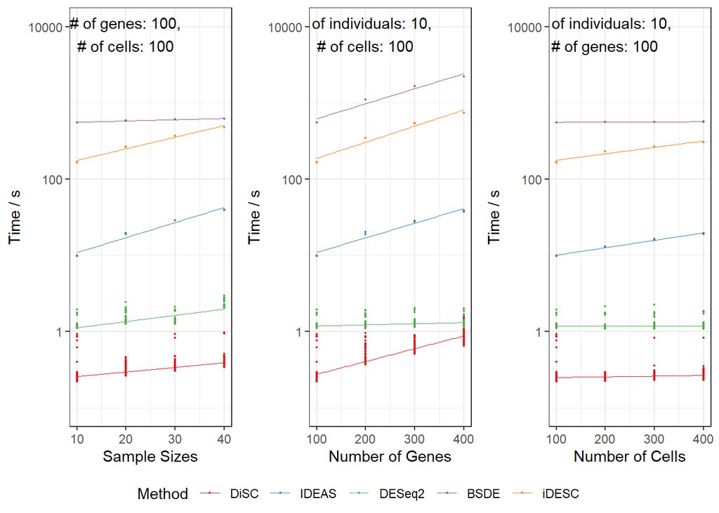

```r
# for increased sample sizes, number of genes and number of cells
comp_time <- readRDS("res_to_rev/response_comp_time/time_results_0107.rds")
levels(comp_time$expr) <- str_remove(levels(comp_time$expr), "_anal.*$")
comp_time <- comp_time %>% # nsample in these data are for one single arm
  dplyr::rename("Method" = "expr") %>%
  mutate(Method = fct_relevel(Method, "DiSC","IDEAS","DESeq2", "BSDE","iDESC"),
         "Time (s)" = time / 1e9)

options(scipen = 3)
N_gene <- which.max(tabulate(comp_time$ngene)) # the most used level
N_cell <- which.max(tabulate(comp_time$ncell))
N_sample <- which.max(tabulate(comp_time$nsample))
# temp <- comp_time %>%
#   mutate(sample_fig = (ngene == N_gene & ncell == N_cell),
#          gene_fig = (nsample == N_sample & ncell == N_cell),
#          cell_fig = (nsample == N_sample & ngene == N_gene))
# bind_rows(
#   mutate(filter(temp, sample_fig), y = nsample),
#   mutate(filter(temp, gene_fig), y = ngene),
#   mutate(filter(temp, cell_fig), y = ncell)
# )
fig1 <- comp_time %>%
  filter(ngene == N_gene, ncell == N_cell) %>%
  ggplot(aes(x = nsample*2, y= `Time (s)`, color = `Method`)) + # nsample *2 for two arms
  geom_point(size=0.3) +
  geom_smooth(method = "lm", formula = y ~ x, se = FALSE, linewidth = 0.3) +
  xlab("Sample Sizes") + ylab("Time / s") +
  scale_y_log10(limits = c(0.1, 10000)) +
  scale_color_brewer(palette = "Set1", name = "Method") +
  annotate("text", x=20, y=8000,
           label= str_glue("# of genes: {N_gene},\n# of cells: {N_cell}"))+
  theme_bw()
fig2 <- comp_time %>%
  filter(nsample == N_sample, ncell == N_cell) %>%
  ggplot(aes(x = ngene, y= `Time (s)`, color = `Method`)) +
  geom_point(size=0.3) +
  geom_smooth(method = "lm", formula = y ~ x, se = FALSE, linewidth = 0.3) +
  xlab("Number of Genes") + ylab("Time / s") +
  scale_y_log10(limits = c(0.1, 10000)) +
  scale_color_brewer(palette = "Set1", name = "Method") +
  annotate("text", x=200, y=8000,
           label= str_glue("# of individuals: {N_sample*2},\n# of cells: {N_cell}"))+
  theme_bw()
fig3 <- comp_time %>%
  filter(nsample == N_sample, ngene == N_gene) %>%
  ggplot(aes(x = ncell, y= `Time (s)`, color = `Method`)) +
  geom_point(size=0.3) +
  geom_smooth(method = "lm", formula = y ~ x, se = FALSE, linewidth = 0.3) +
  xlab("Number of Cells") + ylab("Time / s") +
  scale_y_log10(limits = c(0.1, 10000)) +
  scale_color_brewer(palette = "Set1", name = "Method") +
  annotate("text", x=200, y=8000,
           label= str_glue("# of individuals: {N_sample*2},\n# of genes: {N_gene}"))+
  theme_bw()

time_fig <-
  ggarrange(fig1, fig2, fig3, ncol = 3,
            legend = "bottom", common.legend = TRUE)

time_fig
```

[figure not shown]

```r
# for typical datasets
comp_time_ng2000_nc375_ns24 <-
  readRDS("res_to_rev/response_comp_time/time_results_ng2000_nc375_ns24_0107.rds")
comp_time_ng2000_nc375_ns24$ngene = 2000
comp_time_ng2000_nc375_ns24$ncell = 375
comp_time_ng2000_nc375_ns24$nsample = 24 # do not need to x2 here
comp_time_ng8000_nc1000_ns100 <-
  readRDS("res_to_rev/response_comp_time/time_results_ng8000_nc1000_ns400_0107.rds")
comp_time_ng8000_nc1000_ns100$ngene = 8000
comp_time_ng8000_nc1000_ns100$ncell = 1000
comp_time_ng8000_nc1000_ns100$nsample = 400
comp_time_typical <- bind_rows(comp_time_ng2000_nc375_ns24,
                               comp_time_ng8000_nc1000_ns100)
temp <- levels(comp_time_typical$expr)
temp[str_detect(temp, "^DiSC") &
       str_detect(temp, "perm.no = 99\\)$")] <- "DiSC_99"
temp[str_detect(temp, "^DiSC") &
       str_detect(temp, "perm.no = 999\\)$")] <- "DiSC"
temp <- str_remove(temp, "_anal.*$")
levels(comp_time_typical$expr) <- temp
time_tab <- comp_time_typical %>%
  filter(expr != "DiSC_99") %>%
  bind_rows(data.frame(expr = c("IDEAS", "iDESC", "BSDE"), time = NA,
                       ngene = 8000, ncell = 1000, nsample = 400),
            data.frame(expr = c("iDESC", "BSDE"), time = NA,
                       ngene = 2000, ncell = 375, nsample = 24)
            ) %>%
  mutate(Time = time/1e9) %>%
  mutate(`Dataset` =
           str_c(nsample, " individuals, ",
                 ncell, " cells each, ",
                 ngene, " genes sequenced")) %>%
  dplyr::rename("Method" = "expr") %>%
  group_by(Method, `Dataset`) %>%
  summarise(.groups = "drop",
            `Computational Time /s` =
              str_c(round(mean(Time),1), "±", round(sd(Time),1), sep = " ")) %>%
  replace_na(list(`Computational Time /s` = "> 1800")) %>%
  arrange(`Dataset`,
          match(Method, c("DiSC","IDEAS","DESeq2","BSDE","iDESC"))) %>%
  pivot_wider(id_cols = `Dataset`, names_from = Method,
              values_from = `Computational Time /s`) %>%
  ggtexttable(., rows = NULL, theme = ttheme("blank"))%>%
  tbody_add_border() %>% thead_add_border() %>%
  tab_add_title(text = "Computation Time (in Seconds) for Different Differential Expression Analysis Methods", face = "bold")

time_tab
```

[figure not shown]

```r
time_figure_combined <-
  ggarrange(time_fig, time_tab, labels = c("(a)", "(b)"),
            ncol = 1, nrow = 2, heights = c(1, 0.3),
            font.label = list(size = 12, color = "black",
                              face = "plain", family = NULL))
time_figure_combined
```

```r
ggsave(filename = "results/comp_time_rev.jpeg", time_figure_combined,
       width = 9, height = 6)
ggsave(filename = "results/comp_time_rev.pdf" , time_figure_combined,
       width = 9, height = 6)
```

## GO enrichment analysis on those DiSC-specific DE genes

```r
firstup <- function(x) {
  # uppercase the first letter in GO descriptions
  substr(x, 1, 1) <- toupper(substr(x, 1, 1))
  x
}
pval_thre = 0.10 # the FDR threshold
competing_methods = c("DiSC", "IDEAS", "DESeq2")
#list the results and convert them to a dataframe
res <- list.files("real_data_anal/res/") %>%
  # should look like "d@COVIDPBMC-m@DESeq2-v@0612-c@B_cell.rds"
  # "varname@value" and splitted by "-"
  str_subset(pattern = ".rds$") %>%
  str_remove(pattern = ".rds$") %>%
  sapply(X = ., simplify = FALSE, FUN = \(x){
    temp <- str_split(str_split_1(x, "-"), "@", simplify = TRUE)
    return(c(filname = str_glue("{x}.rds"),
             setNames(object = temp[,2], nm = temp[,1])))
  }) %>%
  bind_rows()
res <- res %>%
  filter(d == "COVIDPBMC" & v == "0612") %>%
  dplyr::rename(Method = "m", Cell_Type = "c")
num_sig <- numeric(nrow(res))
name_sig <- character(nrow(res))
for(rr in 1:nrow(res)){
  pval_mat <- readRDS(str_glue("real_data_anal/res/{res$filname[rr]}"))
  sig_genes <- colnames(pval_mat)[pval_mat["adjusted", ] <= pval_thre]
  sig_genes <- sig_genes[!is.na(sig_genes)] # some values can be NAs in DESeq2
  name_sig[rr] <- str_c(sig_genes, collapse = "::")
  num_sig[rr] <- length(sig_genes)
  rm(pval_mat)
}
res <- res %>%
  mutate(num_sig = num_sig, name_sig = name_sig) %>%
  mutate(Method = factor(Method, levels = competing_methods)) %>%
  mutate(Cell_Type = factor(Cell_Type)) %>%
  # order the cell types according to the how many significant genes DiSC found
  mutate(Cell_Type = fct_reorder2(.f = Cell_Type, .x = Method, .y = num_sig,
                                  .desc = FALSE,
                                  .fun = \(.x, .y) return(.y[.x == "DiSC"])))

deg_CD4 <- res %>%
  filter(Cell_Type == "CD4", Method == "DiSC") %>%
  pull(name_sig) %>%
  str_split_1(pattern = "::")
deg_CD4_other_methods <- res %>%
  filter(Cell_Type == "CD4", Method != "DiSC") %>%
  pull(name_sig) %>%
  str_c(collapse = "::") %>%
  str_split_1(pattern = "::") %>%
  unique()
deg_CD4_DiSC_only <- setdiff(deg_CD4, deg_CD4_other_methods)
cat(str_glue("Number of DEGs identified by DiSC: {length(deg_CD4)}. Number of DEGs identified by DiSC only but not DESeq2 oe IDEAS: {length(deg_CD4_DiSC_only)}\n\n"))
```

```
## Number of DEGs identified by DiSC: 1014. Number of DEGs identified by DiSC only but not DESeq2 oe IDEAS: 809
```

```r
go_enrichment_CD4_BP <- enrichGO(gene = deg_CD4_DiSC_only, OrgDb = "org.Hs.eg.db",
                                 keyType = "SYMBOL", ont = "BP")
go_enrichment_CD4_BP <- go_enrichment_CD4_BP %>%
  as_tibble() %>%
  mutate(ratio = sapply(GeneRatio, function(txt) eval(parse(text=txt)),
                        simplify = TRUE)) %>%
  mutate(`-log_p` = -log10(p.adjust))
go_enrichment_CD4_BP_10 <-  go_enrichment_CD4_BP %>%
  slice_max(order_by = `-log_p`, n = 10) %>%
  mutate(Description = firstup(Description)) %>%
  mutate(Description = stringr::str_wrap(Description, width = 40))

deg_CD8 <- res %>%
  filter(Cell_Type == "CD8", Method == "DiSC") %>%
  pull(name_sig) %>%
  str_split_1(pattern = "::")
deg_CD8_other_methods <- res %>%
  filter(Cell_Type == "CD8", Method != "DiSC") %>%
  pull(name_sig) %>%
  str_c(collapse = "::") %>%
  str_split_1(pattern = "::") %>%
  unique()
deg_CD8_DiSC_only <- setdiff(deg_CD8, deg_CD8_other_methods)
cat(str_glue("Number of DEGs identified by DiSC: {length(deg_CD8)}. Number of DEGs identified by DiSC only but not DESeq2 oe IDEAS: {length(deg_CD8_DiSC_only)}\n\n"))
```

```
## Number of DEGs identified by DiSC: 985. Number of DEGs identified by DiSC only but not DESeq2 oe IDEAS: 594
```

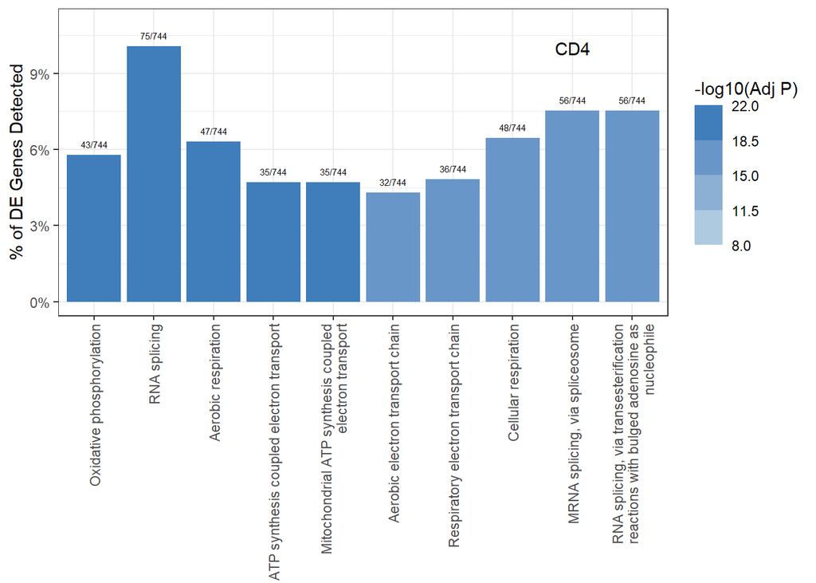

```r
go_enrichment_CD8_BP <- enrichGO(gene = deg_CD8_DiSC_only, OrgDb = "org.Hs.eg.db",
                                 keyType = "SYMBOL", ont = "BP")
go_enrichment_CD8_BP <- go_enrichment_CD8_BP %>%
  as_tibble() %>%
  mutate(ratio = sapply(GeneRatio, function(txt) eval(parse(text=txt)),
                        simplify = TRUE)) %>%
  mutate(`-log_p` = -log10(p.adjust))
go_enrichment_CD8_BP_10 <-  go_enrichment_CD8_BP %>%
  slice_max(order_by = `-log_p`, n = 10) %>%
  mutate(Description = firstup(Description)) %>%
  mutate(Description = stringr::str_wrap(Description, width = 40))

log_p_comb <- c(go_enrichment_CD4_BP_10$`-log_p`,
                go_enrichment_CD8_BP_10$`-log_p`)
go_breaks <- seq(from = floor(min(log_p_comb)), to = ceiling(max(log_p_comb)),
                 length.out = 5)
figure_GO_CD4 <- go_enrichment_CD4_BP_10 %>%
  mutate(Description = fct_reorder(Description, `-log_p`, .desc = TRUE)) %>%
  ggplot(aes(x = Description, y = ratio, fill = `-log_p`)) +
  geom_bar(stat = "identity")+
  geom_text(label = go_enrichment_CD4_BP_10$GeneRatio, vjust=-1, size = 2)+
  scale_y_continuous(labels = scales::percent, limits = c(0, 0.11)) +
  scale_fill_steps(name = "-log10(Adj P)", breaks = go_breaks,
                   limits = c(min(go_breaks), max(go_breaks)),
                   low = "#bdd7e7", high = "#2171b5")+
  theme_bw()+labs(x = NULL, y = "% of DE Genes Detected")+
  theme(axis.text.x = element_text(angle = 90, vjust = 0.5, hjust=1))+
  annotate("text", x = 9, y= 0.10, label = "CD4")
figure_GO_CD8 <- go_enrichment_CD8_BP_10 %>%
  mutate(Description = fct_reorder(Description, `-log_p`, .desc = TRUE)) %>%
  ggplot(aes(x = Description, y = ratio, fill = `-log_p`)) +
  geom_bar(stat = "identity")+
  geom_text(label = go_enrichment_CD8_BP_10$GeneRatio, vjust=-1, size = 2)+
  scale_y_continuous(labels = scales::percent, limits = c(0, 0.11)) +
  scale_fill_steps(name = "-log10(Adj P)", breaks = go_breaks,
                   limits = c(min(go_breaks), max(go_breaks)),
                   low = "#bdd7e7", high = "#2171b5")+
  theme_bw()+labs(x = NULL, y = "% of DE Genes Detected")+
  theme(axis.text.x = element_text(angle = 90, vjust = 0.5, hjust=1))+
  annotate("text", x = 9, y= 0.10, label = "CD8")
figure_GO_CD4
```

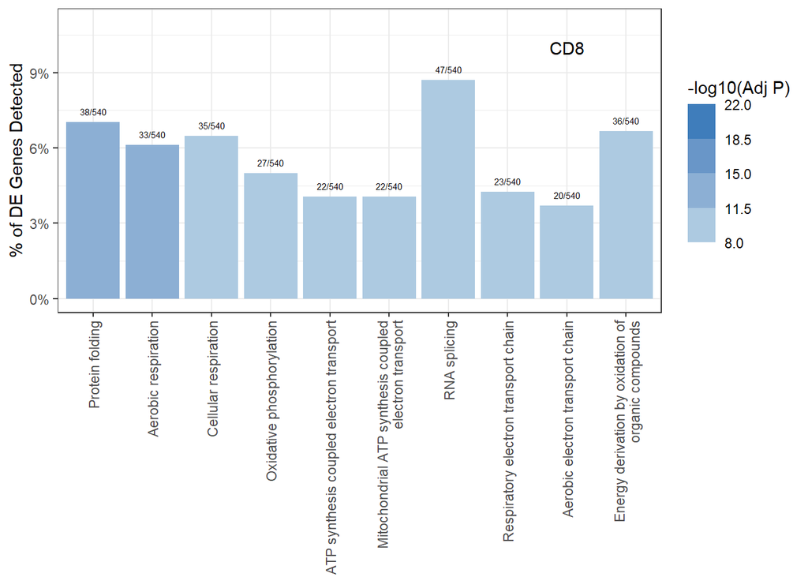

```r
figure_GO_CD8
```

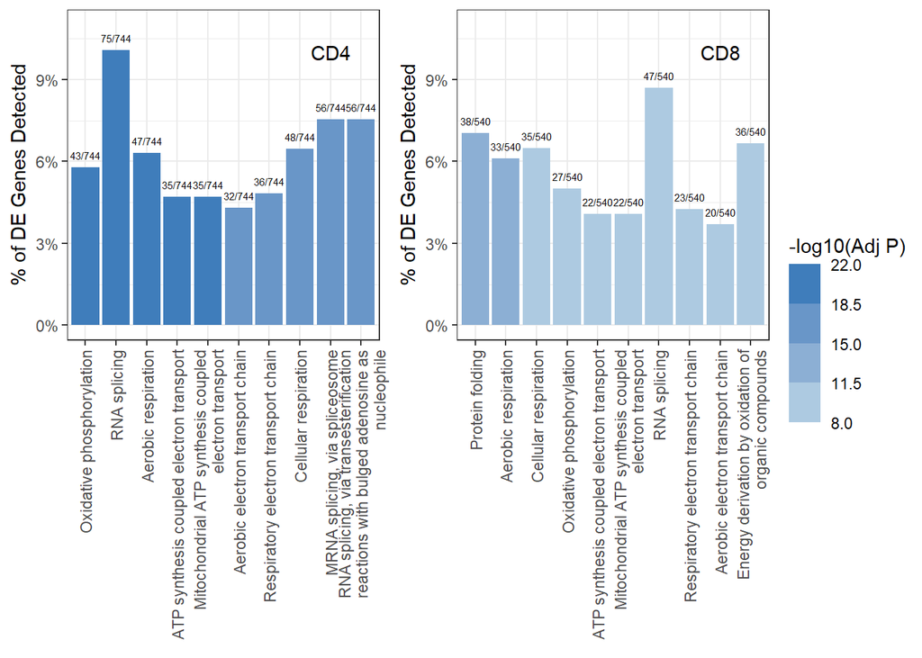

```r
GO_fig <-
  ggarrange(figure_GO_CD4, figure_GO_CD8, ncol = 2,
            legend = "right", common.legend = TRUE)
GO_fig
```

```r
ggsave(filename = "res_to_rev/GO_DiSC_only.jpeg", GO_fig,
       width = 8, height = 5)
```

# Response to reviewer No.2

## More recent methods such as iDESC and BSDE should also be included in the comparisons

```r
# response to reviewers: a comparison of power with methods of iDESC and BSDE

##########################
#parameters to be specified:
#general parameters: WORKINGDIRECTORY, 100
#PARA_OUT, SIMU_D, CAT
#parameters in simulations: DIFF, NCELL, NPG, VNCELL
##########################

setwd("/home/guanwh/zhan7474/mayo/res_to_rev/")

library(tidyverse)
library(Matrix)
library(parallel)
library(doParallel)
library(DESeq2)
library(ideas)
library(qvalue)
library(reticulate)
use_python("/home/guanwh/zhan7474/.conda/envs/r_env/bin/python", required = TRUE)
use_condaenv("/home/guanwh/zhan7474/.conda/envs/r_env", required = TRUE)
library(BSDE)
library(iDESC)
source("DiSC.R")


set.seed(seed = 12345181)
n.cores = 100
DATE = "0811"# the date when simulation datasets were created
parameters <- "VNCELL=FALSE;DIFF=1.3;NCELL=375;NPG=12;BOOT=20" # we use the first 20 of the 50 datasets

tryCatch({
  for(paras in parameters){
    cat("Using parameters:", paras)
    eval(parse(text=paras)) # VNCELL=FALSE;DIFF=1.1;NCELL=375;NPG=12;BOOT=50
    boot = BOOT
    diff = exp(abs(log(DIFF))) #promise diff >= 1
    n_cas = NPG
    n_ctr = NPG
    nall = n_cas + n_ctr
    neq_n_cell = VNCELL
    n_cell= NCELL

    for(bbbb in 1:boot){
        conf <- str_glue("n{n_cas}_{n_ctr}_d{diff}_c{n_cell}_v{neq_n_cell}_{DATE}_b{bbbb}")
        load(str_glue("/home/guanwh/zhan7474/mayo/para_data_sim/{conf}.RData"))
        count_matrix = dat_list$count_matrix
        meta_cell = dat_list$meta_cell
        meta_cell$phenotype = factor(ifelse(meta_cell$phenotype == 1, "case", "control"))
        names(meta_cell)[which(names(meta_cell) == "cell_rd")] <- "read_depth"
        meta_ind = dat_list$meta_ind
        meta_ind$phenotype = factor(ifelse(meta_ind$phenotype == 1, "case", "control"))
        var2test = "phenotype"
        var2adjust = NULL
        var2test_type = "binary"
        if(bbbb == 1)
            saveRDS(object = dat_list$gene_index, file = str_glue("geneidx_null_{conf}.rds"))
        #source("DiSC.R")
        # using count_matrix, meta_cell, meta_ind, var2test, var2adjust in the memory
        # determine the test type based on the type of meta_ind[[var2test]]
        # always create a "pval_mat" in the memory

        # DiSC
        mth = "DiSC"
        if(!file.exists(str_glue("results_{mth}_{conf}.rds"))){
            # _ may have been used in ctp
            #d: dataset, m: method, v: version, c: cell type
            source(str_glue("{mth}_anal.R"))
            saveRDS(object = pval_mat,
                    file = str_glue("results_{mth}_{conf}.rds"))
        }

        # IDEAS
        mth = "IDEAS"
        if(!file.exists(str_glue("results_{mth}_{conf}.rds"))){
            registerDoParallel(cores=n.cores)
            options(mc.cores=n.cores)
            RNGkind("L'Ecuyer-CMRG")
            source(str_glue("{mth}_anal.R"))
            saveRDS(object = pval_mat,
                    file = str_glue("results_{mth}_{conf}.rds"))
            stopImplicitCluster()
        }

        # DESeq2
        mth = "DESeq2"
        if(!file.exists(str_glue("results_{mth}_{conf}.rds"))){
            source(str_glue("{mth}_anal.R"))
            saveRDS(object = pval_mat,
                    file = str_glue("results_{mth}_{conf}.rds"))
        }

        # BSDE
        mth = "BSDE"
        if(!file.exists(str_glue("results_{mth}_{conf}.rds"))){
            cl <- makeCluster(n.cores) # BSDE_anal.R requires additionally cl in the memory
            source(str_glue("{mth}_anal.R"))
            stopCluster(cl)
            rm(cl)
            saveRDS(object = pval_mat,
                    file = str_glue("results_{mth}_{conf}.rds"))
        }

        # iDESC
        mth = "iDESC"
        if(!file.exists(str_glue("results_{mth}_{conf}.rds"))){
            n.cores = n.cores
            cl <- makeCluster(n.cores) # iDESC_anal.R requires additionally cl in the memory
            source(str_glue("{mth}_anal.R"))
            stopCluster(cl)
            rm(cl)
            saveRDS(object = pval_mat,
                    file = str_glue("results_{mth}_{conf}.rds"))
        }

        cat(str_glue("finished {conf}\n\n"))
    }
}}, error=function(err){
  # exception handling. See the part above
  # if error occurs, save current work image and restart outside
  print(err)
  print("Need to be restarted...")
  save.image(file = str_glue("unfinished_{conf}.RData"))
  q(save = "no")
  return(0)
})# try-catach part

q(save = "no")
```

```r
thre_raw = 0.05
thre_adj = 0.10
res <- list.files("res_to_rev/response_more_methods/") %>%
  # should look like "results_BSDE_n12_12_d1.3_c375_vFALSE_0811_b1.RData"
  # but there is a typo that they are actually .rds file
  # need to rename all the files into .rds before running the code
  str_subset(pattern = ".rds$")
res <- res %>%
  str_remove(pattern = ".rds$") %>%
  str_split("_", simplify = TRUE) %>%
  cbind(res) %>%
  magrittr::set_colnames(c("Results", "Method", "N_Cas", "N_Ctr", "Effect_Size",
                           "N_Cell", "Var_Cell", "Version", "Iteration", "Filename")) %>%
  as_tibble() %>%
  mutate(N_Cas = as.numeric(str_remove(N_Cas, "n")),
         N_Ctr = as.numeric(N_Ctr),
         N_tot = N_Cas + N_Ctr,
         Effect_Size = as.numeric(str_remove(Effect_Size, "d")),
         N_Cell = as.numeric(str_remove(N_Cell, "c")),
         Var_Cell = as.logical(str_remove(Var_Cell, "v")),
         Iteration = as.numeric(str_remove(Iteration, "b"))) %>%
  filter(Results == "results") %>%
  mutate(num_NA = -1,
         num_sig_mean_raw = -1, num_sig_var_raw = -1, num_sig_mv_raw = -1,num_sig_ee_raw = -1,
         num_sig_mean_adj = -1, num_sig_var_adj = -1, num_sig_mv_adj = -1,num_sig_ee_adj = -1)
gene_index <- readRDS(str_glue("res_to_rev/response_more_methods/geneidx_null_n12_12_d1.3_c375_vFALSE_0811_b1.rds"))

for(rr in 1:nrow(res)){
  pval_mat <- readRDS(str_glue("res_to_rev/response_more_methods/{res$Filename[rr]}"))
  if(rr == 1) ngene <- dim(pval_mat)[2]

  pval_raw <- pval_mat["raw", ]
  res$num_NA[rr] <- sum(is.na(pval_raw))

  res$num_sig_mean_raw[rr] <- sum(pval_raw[gene_index$mean_index] <= thre_raw, na.rm = TRUE)
  res$num_sig_var_raw[rr]  <- sum(pval_raw[gene_index$var_index]  <= thre_raw, na.rm = TRUE)
  res$num_sig_mv_raw[rr]   <- sum(pval_raw[gene_index$mean_var_index] <= thre_raw, na.rm = TRUE)
  res$num_sig_ee_raw[rr]   <- sum(pval_raw[gene_index$EE_index]   <= thre_raw, na.rm = TRUE)

  if(res$Method[rr] %in% c("BSDE", "IDEAS", "iDESC")){
    pi0 = 2*sum(pval_raw > 0.5, na.rm = TRUE)/sum(!is.na(pval_raw))
    # really need this pi0, otherwise in some cases, error will occur
    pi0 = ifelse(pi0>1, 1, ifelse(pi0<0.5, 0.5, pi0)) # 0.5<=pi0<=1
    pval_adj <- qvalue::qvalue(pval_raw, pi0=pi0)$qvalues
  } else if(res$Method[rr] %in% c("DiSC", "DESeq2")){
    pval_adj <- pval_mat["adjusted",]
  }

  res$num_sig_mean_adj[rr] <- sum(pval_adj[gene_index$mean_index] <= thre_adj, na.rm = TRUE)
  res$num_sig_var_adj[rr]  <- sum(pval_adj[gene_index$var_index]  <= thre_adj, na.rm = TRUE)
  res$num_sig_mv_adj[rr]   <- sum(pval_adj[gene_index$mean_var_index] <= thre_adj, na.rm = TRUE)
  res$num_sig_ee_adj[rr]   <- sum(pval_adj[gene_index$EE_index]   <= thre_adj, na.rm = TRUE)
}
# DESeq2: when allowing independentFiltering and cooksCutoff, p-values for some
# genes may be returned as NA. They are assumed to be non-significant genes
# IDEAS: NA values at 1 or 2 genes. For an assessment of FDR and type I error,
# it should be fine
# iDESC: convergence issues occur in 7-10% of genes and returned NA values
# Model convergence problem; non-positive-definite Hessian matrix; NA values for likelihood/AIC/etc.
# false convergence
res %>%
  tableone::CreateCatTable(vars = c("num_NA"), strata = "Method",
                           data = ., test = FALSE)
```

```
##             Stratified by Method
##              BSDE        DESeq2      DiSC        IDEAS      iDESC
##   n          20          20          20          20         20
##   num_NA (%)
##      0       20 (100.0)  20 (100.0)  20 (100.0)   1 ( 5.0)  0 (0.0)
##      1        0 (  0.0)   0 (  0.0)   0 (  0.0)  17 (85.0)  0 (0.0)
##      2        0 (  0.0)   0 (  0.0)   0 (  0.0)   2 (10.0)  0 (0.0)
##      571      0 (  0.0)   0 (  0.0)   0 (  0.0)   0 ( 0.0)  1 (5.0)
##      595      0 (  0.0)   0 (  0.0)   0 (  0.0)   0 ( 0.0)  1 (5.0)
##      598      0 (  0.0)   0 (  0.0)   0 (  0.0)   0 ( 0.0)  1 (5.0)
##      599      0 (  0.0)   0 (  0.0)   0 (  0.0)   0 ( 0.0)  1 (5.0)
##      613      0 (  0.0)   0 (  0.0)   0 (  0.0)   0 ( 0.0)  1 (5.0)
##      629      0 (  0.0)   0 (  0.0)   0 (  0.0)   0 ( 0.0)  1 (5.0)
##      641      0 (  0.0)   0 (  0.0)   0 (  0.0)   0 ( 0.0)  1 (5.0)
##      643      0 (  0.0)   0 (  0.0)   0 (  0.0)   0 ( 0.0)  1 (5.0)
##      649      0 (  0.0)   0 (  0.0)   0 (  0.0)   0 ( 0.0)  1 (5.0)
##      654      0 (  0.0)   0 (  0.0)   0 (  0.0)   0 ( 0.0)  1 (5.0)
##      690      0 (  0.0)   0 (  0.0)   0 (  0.0)   0 ( 0.0)  1 (5.0)
##      719      0 (  0.0)   0 (  0.0)   0 (  0.0)   0 ( 0.0)  1 (5.0)
##      720      0 (  0.0)   0 (  0.0)   0 (  0.0)   0 ( 0.0)  1 (5.0)
##      739      0 (  0.0)   0 (  0.0)   0 (  0.0)   0 ( 0.0)  1 (5.0)
##      750      0 (  0.0)   0 (  0.0)   0 (  0.0)   0 ( 0.0)  1 (5.0)
##      768      0 (  0.0)   0 (  0.0)   0 (  0.0)   0 ( 0.0)  1 (5.0)
##      786      0 (  0.0)   0 (  0.0)   0 (  0.0)   0 ( 0.0)  1 (5.0)
##      790      0 (  0.0)   0 (  0.0)   0 (  0.0)   0 ( 0.0)  1 (5.0)
##      799      0 (  0.0)   0 (  0.0)   0 (  0.0)   0 ( 0.0)  1 (5.0)
##      835      0 (  0.0)   0 (  0.0)   0 (  0.0)   0 ( 0.0)  1 (5.0)
```

```r
summarise_CI95 <- function(x, percentage = TRUE, digits = 2){
  x <- x[!is.na(x)]
  nx <- length(x)
  center <- mean(x)
  se <- sd(x)/sqrt(nx)
  upper <- center + 1.96*se
  lower <- center - 1.96*se
  if(percentage)
    return(str_glue("{round(center*100, digits)} ({round(lower*100, digits)}, {round(upper*100, digits)})")) else
      return(str_glue("{round(center, digits)} ({round(lower, digits)}, {round(upper, digits)})"))
}
tbl.temp <- res %>%
  dplyr::select(Method, Iteration, starts_with("num")) %>%
  mutate(pr_sig_mean_raw = num_sig_mean_raw/length(gene_index$mean_index),
         pr_sig_var_raw  = num_sig_var_raw /length(gene_index$var_index),
         pr_sig_mv_raw   = num_sig_mv_raw  /length(gene_index$mean_var_index),
         pr_sig_ee_raw   = num_sig_ee_raw  /length(gene_index$EE_index), # type I error

         pr_sig_mean_adj = num_sig_mean_adj/length(gene_index$mean_index), # power
         pr_sig_var_adj  = num_sig_var_adj /length(gene_index$var_index), # power
         pr_sig_mv_adj   = num_sig_mv_adj  /length(gene_index$mean_var_index), # power
         fdr = num_sig_ee_adj/
           (num_sig_mean_adj+num_sig_var_adj+num_sig_mv_adj+num_sig_ee_adj),
         ) %>%
  group_by(Method) %>%
  summarise(.groups = "drop",
            "False Discovery Proportions (%)" = summarise_CI95(fdr, digits = 1),
            "Positive Findings (%), DE in Mean" = summarise_CI95(pr_sig_mean_adj, digits = 1),
            "Positive Findings (%), DE in Var" = summarise_CI95(pr_sig_var_adj, digits = 1),
            "Positive Findings (%), DE in Both Mean and Var" = summarise_CI95(pr_sig_mv_raw, digits = 1)
            ) %>%
  dplyr::select(Method, contains("%")) %>%
  arrange(match(Method, c("DiSC", "IDEAS", "DESeq2", "BSDE", "iDESC"))) %>%
  kbl() %>%
  kable_classic(full_width = F, html_font = "Cambria")
tbl.temp
```

| Method | False Discovery Proportions (%) | Positive Findings (%), DE in Mean | Positive Findings (%), DE in Var | Positive Findings (%), DE in Both Mean and Var |
| --- | --- | --- | --- | --- |
| DiSC | 8.2 (7.6, 8.9) | 36.3 (35.2, 37.4) | 61.3 (60, 62.5) | 90.5 (90, 90.9) |
| IDEAS | 10.4 (9.1, 11.7) | 22.2 (20.6, 23.7) | 1.1 (0.9, 1.3) | 46.4 (45.2, 47.7) |
| DESeq2 | 17.6 (15.9, 19.3) | 40.3 (39.2, 41.4) | 0.9 (0.7, 1.1) | 61.4 (60.5, 62.3) |
| BSDE | 9.4 (8.5, 10.4) | 32.2 (31.3, 33.1) | 1 (0.8, 1.2) | 57.1 (56.3, 57.9) |
| iDESC | 25.7 (14.2, 37.2) | 27.2 (21.9, 32.5) | 31 (25.6, 36.4) | 75.3 (71.8, 78.8) |

```r
# from parametric simulation

EE1.2 <- readRDS("res_to_rev/EE1.2.rds")
DE1.2 <- readRDS("res_to_rev/DE1.2.rds")
EE2.2 <- readRDS("res_to_rev/EE2.2.rds")
DE2.2 <- readRDS("res_to_rev/DE2.2.rds")
EE3.2 <- readRDS("res_to_rev/EE3.2.rds")
DE3.2 <- readRDS("res_to_rev/DE3.2.rds")

figure_para_sim <-
  ggarrange(EE1.2, DE1.2, EE3.2, DE3.2, EE2.2, DE2.2,
            widths = c(1,3), ncol = 2, nrow = 3,
            legend = "bottom", common.legend = TRUE,
            labels = c("(a)", NA, "(b)", NA, "(c)", NA),
            font.label = list(size = 12, color = "black",
                              face = "plain", family = NULL))
ggsave(filename = "results/para_sim_rev.jpeg", figure_para_sim,
       width = 8, height = 9)
ggsave(filename = "results/para_sim_rev.jpeg" , figure_para_sim,
       width = 8, height = 9)
```

## More real data analyses

The Alzheimer’s disease (SEA-AD) dataset was originally obtained by Gabitto et al. (2024) to gain a deep molecular and cellular understanding of the early pathogenesis of Alzheimer’s disease using single-nuclei multi-omics method.

The snRNA-seq (single nuclei RNA sequencing) data matrix and metadata can be retrieved from https://cellxgene.cziscience.com/collections/1ca90a2d-2943-483d-b678-b809bf464c30.

```r
library(tidyverse)
library(Matrix)
library(Seurat)

# workdir = "/home/guanwh/zhan7474/mayo/real_data_anal/AD"

thre_n_cell_per_individual = 30
thre_mito_pct = 5
min_qt_UMI_per_cell = 0.05 # 5% quantile
max_qt_UMI_per_cell = 0.98 # 99% quantile
SPARSITY_THRESHOLD = 0.6 #or NULL. Keep genes with sparsity < SPARSITY_THRESHOLD
options(timeout=600)

# more filtering to reduce computational time (IDEAS will take too much time)
ngene_2_keep = 5000
ncell_2_keep = 250
get_n_cell <- function(read_depth, ncell_2_keep = 300){
  n_cell <- length(read_depth)
  if(ncell_2_keep >= n_cell)
    return(rep(TRUE, n_cell))
  HDI <- HDInterval::hdi(read_depth, credMass= ncell_2_keep/n_cell, allowSplit = FALSE)
  return(read_depth >= HDI["lower"] & read_depth < HDI["upper"])
}

setwd("/home/guanwh/zhan7474/mayo/res_to_rev/")

cell_type_fp = c(
  Lamp5_Lhx6 = "https://datasets.cellxgene.cziscience.com/3d690bcf-c9d3-4fcf-b7e1-e0e622bbf958.rds",
  Lamp5 = "https://datasets.cellxgene.cziscience.com/abc02bdf-8bb7-42dd-8d5f-eff48fb8225b.rds",
  Pax6 = "https://datasets.cellxgene.cziscience.com/a2ee847d-c5b4-4318-b6ba-0d36ed57d769.rds",
  Sncg = "https://datasets.cellxgene.cziscience.com/ee226a77-6ec1-4a16-b653-8cbacd3876bc.rds",
  Vip = "https://datasets.cellxgene.cziscience.com/08f013eb-107a-4f25-a8b2-4ebb30f6e7ea.rds",
  Chandelier = "https://datasets.cellxgene.cziscience.com/7bb8238f-b5a7-4bbd-9c00-244e2b72e140.rds",
  Pvalb = "https://datasets.cellxgene.cziscience.com/bcdf1ef7-3129-4de8-87a2-066978199d5f.rds",
  Sst = "https://datasets.cellxgene.cziscience.com/b52e6423-1687-49cc-bf31-810c055b6656.rds",
  Sst_Chodl = "https://datasets.cellxgene.cziscience.com/1ac8ed44-27f6-4ade-96e6-e703cb171cfc.rds",
  # L2_3_IT = "https://datasets.cellxgene.cziscience.com/f9e42464-5984-4c77-99ea-9c6d6c130897.h5ad",
  L4_IT = "https://datasets.cellxgene.cziscience.com/94717711-bdeb-4002-94bf-4098b969b061.rds",
  L5_IT = "https://datasets.cellxgene.cziscience.com/2af5392b-7579-43be-bacc-40f67e921fc7.rds",
  L6_IT = "https://datasets.cellxgene.cziscience.com/a37f85f1-4ef4-4d8f-8a65-63e45441b006.rds",
  L6_IT_Car3 = "https://datasets.cellxgene.cziscience.com/5f78b6bc-57ff-469d-ab6a-91787159e88f.rds",
  L5_ET = "https://datasets.cellxgene.cziscience.com/9d53f7bb-dc23-4c05-b2a6-4afa9a6e3be0.rds",
  L5_6_NP = "https://datasets.cellxgene.cziscience.com/97112340-5db0-423a-8077-9386c1b815ff.rds",
  L6b = "https://datasets.cellxgene.cziscience.com/922bd0fa-edd7-44e8-bc7c-59de700a686b.rds",
  L6_CT = "https://datasets.cellxgene.cziscience.com/8406fa2b-a671-4f7f-aaeb-0877e61a2a04.rds",
  Astrocyte = "https://datasets.cellxgene.cziscience.com/eb9ac67f-3041-4cb8-85d4-8616931cc218.rds",
  Oligodendrocyte = "https://datasets.cellxgene.cziscience.com/32b747ce-7afb-4342-89d2-ca5d274164ed.rds",
  OPC = "https://datasets.cellxgene.cziscience.com/8172e13e-dfa0-44fc-aec5-3988ace41f37.rds",
  Endothelial = "https://datasets.cellxgene.cziscience.com/d4f4d813-aa81-4fd9-a12d-b4a60788b604.rds",
  VLMC = "https://datasets.cellxgene.cziscience.com/0fd1a3ed-51fd-44ba-808c-9b94f3ff88da.rds",
  Microglia_PVM = "https://datasets.cellxgene.cziscience.com/32b32549-9c68-453d-91c6-74acad9df928.rds"
)

cell_types <- names(cell_type_fp)

# variables should be included in the meta
var_interested_cell <- c("cell", "Number of UMIs", "Fraction mitochrondrial UMIs", "assay")
var_interested_indi <- c("donor_id", "disease",
                         "Age at death", "sex", "self_reported_ethnicity")
var_interested <- c(var_interested_cell, var_interested_indi)

for(ctp in cell_types){ #ctp = cell_types[1]
  cat("#########################################################\n")
  cat("Cleaning data for cell type:", ctp, "\n")
  cat("#########################################################\n")

  DATA <- readRDS(url(cell_type_fp[ctp]))
  ct_mat <- LayerData(DATA, assay = "RNA", layer = "counts") # looks good
  meta <- DATA[[]]
  meta$cell <- rownames(meta)

  #######################################
  # check meta and ct_mat
  #######################################
  meta = droplevels(meta)
  print(str(meta))
  for(vv in var_interested)
    stopifnot(vv %in% names(meta)) #an error occurs when any of var_interested is not in meta
  stopifnot(inherits(meta[["cell"]], "character"))
  stopifnot(inherits(meta[["assay"]], "factor"))
  stopifnot(inherits(meta[["Number of UMIs"]], "numeric"))
  stopifnot(inherits(meta[["Fraction mitochrondrial UMIs"]], "numeric"))
  stopifnot(inherits(meta[["donor_id"]], "factor")) # this should be converted to character
  stopifnot(inherits(meta[["disease"]], "factor"))
  stopifnot(inherits(meta[["Age at death"]], "factor")) # this should be converted to numeric
  stopifnot(inherits(meta[["sex"]], "factor"))
  stopifnot(inherits(meta[["self_reported_ethnicity"]], "factor"))

  stopifnot(inherits(ct_mat, "dgCMatrix"))
  stopifnot(sum(colnames(ct_mat) != meta[["cell"]]) == 0)
  read_depth <- colSums(ct_mat)
  if(sum(read_depth != meta[["Number of UMIs"]]) != 0){
    cat("colSums(ct_mat) != Number of UMIs\n")
    if(sum(read_depth > meta[["Number of UMIs"]]) == 0){
      cat("colSums(ct_mat) <= Number of UMIs\n")
      # this may be because some sequences have been discarded in QC steps

      index <-
        (read_depth <= quantile(read_depth, max_qt_UMI_per_cell)) &
        (read_depth >= quantile(read_depth, min_qt_UMI_per_cell))
      diff = read_depth - meta[["Number of UMIs"]]
      cat("summary of the difference:\n")
      print(summary(diff[index]))
      # We will remove insufficiently sequenced cells and overly deeply sequenced cells later
      # As long as the Number of UMIs in the remaining cells is close to read_depth
      # it is good to replace Number of UMIs with colSums(ct_mat), or read_depth
      cat("summary of the difference in percentage:\n")
      frac = diff / meta[["Number of UMIs"]]
      print(summary(frac[index]))

      if(max(abs(frac[index])) <= 0.03){
        cat("Number of UMIs * 0.97 <= colSums(ct_mat) <= Number of UMIs\n")
        cat("Replacing Number of UMIs with colSums(ct_mat)\n")
        # when the difference is small, "Fraction mitochrondrial UMIs" are still considerably accurate
        # Fraction mitochrondrial UMIs = 5% -> 5.15%
        meta[["Number of UMIs"]] <- read_depth
      } else {
        stop("for some colSums(ct_mat) < 0.97 * Number of UMIs! It may be inaccurate to replace Number of UMIs")
      }
    } else {
      stop("for some colSums(ct_mat) > Number of UMIs!!!!!")
    }
  }
  stopifnot(sum(colSums(ct_mat) != meta[["Number of UMIs"]]) == 0)
```

```r
  ############################################
  # clean the dataset
  ############################################
  meta_cleaned <- meta
  ##outcome of interest: disease (dementia vs normal)
  table(meta_cleaned[["Cognitive status"]], meta_cleaned[["disease"]])
  ##one donor can have multiple specimens
  # table(meta_cleaned[["donor_id"]], meta_cleaned[["Specimen ID"]])
  ##check if each individual will have a unique value for outcome of interest and covariates
  cat("# of individuals:", length(unique(meta_cleaned[["donor_id"]])), "\n")
  stopifnot(length(unique(meta_cleaned[["donor_id"]])) == # unique donors
              nrow(distinct(meta_cleaned, pick(all_of(var_interested_indi)))))
  meta_cleaned %>%
    distinct(donor_id, disease,
             sex, `Age at death`, self_reported_ethnicity) %>%
    tableone::CreateTableOne(data =., vars = setdiff(names(.), c("disease", "donor_id")),
                             strata = c("disease"),
                             includeNA = TRUE, test = FALSE, addOverall = TRUE)%>%
    print()# balanced

  ######################################################
  # filtering and datatype conversion
  ######################################################
  # datatype conversion
  meta_cleaned <- meta_cleaned %>%
    select(all_of(var_interested)) %>%
    rename(individual = "donor_id", cell_id = "cell") %>%
    mutate(individual = as.character(individual)) %>%
    mutate(age_lvl = case_match(`Age at death`,
                                "Less than 65 years old" ~ 1,
                                "65 to 77 years old" ~ 2,
                                "78 to 89 years old" ~ 3,
                                "90+ years old" ~ 4))

  # self_reported_ethnicity: subjects are dominantly European descendants and
  # the sample sizes for other ethnicity are too small (1 or 3 people)
  meta_cleaned <- meta_cleaned %>%
    filter(self_reported_ethnicity == "European") %>%
    filter(assay == "10x 3' v3") # the number squenced by "10x 3' v3" was 9x as many as "10x multiome"


  # mitochrondrial RNA fraction
  print(summary(meta_cleaned[["Fraction mitochrondrial UMIs"]]))
  if(sum(meta_cleaned[["Fraction mitochrondrial UMIs"]] > 1) == 0){
    cat("Fraction mitochrondrial UMIs are decimals. Convert them to percentage\n")
    meta_cleaned[["Fraction mitochrondrial UMIs"]] <-
      meta_cleaned[["Fraction mitochrondrial UMIs"]]*100
  }
  cat(str_glue("number of cells with Fraction mitochrondrial UMIs greater than {thre_mito_pct}: {sum(meta_cleaned[['Fraction mitochrondrial UMIs']]>thre_mito_pct)}\n\n"))
  meta_cleaned <- meta_cleaned %>%
    filter(`Fraction mitochrondrial UMIs` <= thre_mito_pct)

  # number of UMIs
  max_count_UMI_per_cell <-
    quantile(meta_cleaned[["Number of UMIs"]], probs = max_qt_UMI_per_cell)
  min_count_UMI_per_cell <-
    quantile(meta_cleaned[["Number of UMIs"]], probs = min_qt_UMI_per_cell)
  cat("filtering threshold of Number of UMIs: min:", min_count_UMI_per_cell,
      ", max:", max_count_UMI_per_cell, "\n")
  meta_cleaned <- meta_cleaned %>%
    filter(`Number of UMIs` <= max_count_UMI_per_cell &
             `Number of UMIs` >= min_count_UMI_per_cell)

  # filtering insufficient cell per individual
  # this step was less explicit in COVID-PBMC pipeline, where filtering starts
  # with sample_ids -> columns in mat_filtered -> rows in meta_cell
  ncell_tbl <- meta_cleaned %>%
    summarise(ncell = n(), .by = individual)%>%
    filter(ncell < thre_n_cell_per_individual)
  cat(str_glue("individuals with ncell < {thre_n_cell_per_individual}:"),
      ncell_tbl[['individual']], "\n")
  meta_cleaned <- meta_cleaned %>%
    filter(!(individual %in% ncell_tbl[["individual"]]))

  ######################################################
  # creating the required dataset for DE analyses
  ######################################################
  var2test = "disease"
  #var2adjust = c("age_lvl", "sex", "self_reported_ethnicity")
  var2adjust = c("age_lvl", "sex")
  var2test_type = "binary"

  meta_ind <- meta_cleaned %>%
    distinct(pick(all_of(c("individual", var2test, var2adjust)))) %>%
    droplevels()
  if(nrow(meta_ind) < 6){
    cat(str_glue("Sample size too small for {ctp} (<6 individuals). {ctp} will be excluded!\n\n"))
    next
  }
  if(sum(meta_ind[["disease"]] == "normal") < 2){
    cat(str_glue("For {ctp}, we only have 0 or 1 healthy control. {ctp} will be excluded!\n\n"))
    next
  }
  if(sum(meta_ind[["disease"]] == "dementia") < 2){
    cat(str_glue("For {ctp}, we only have 0 or 1 dementia case. {ctp} will be excluded!\n\n"))
    next
  }

  count_matrix <- ct_mat[, colnames(ct_mat) %in% meta_cleaned[["cell_id"]]]
  ## count_matrix, genes in rows and cells in columns
  # no need to convert to dense matrix here. Do it after sparsity filtering
  ngene = nrow(count_matrix)
  ncell = ncol(count_matrix)
  read_depth <- colSums(count_matrix)
  if(ngene < ncell)
    message("the number of genes is smaller than the number of cells, please check if genes are in rows")
  cat("ngene: ", ngene, "ncell: ", ncell, "read_depth[1:10]: ", read_depth[1:10], "\n")
  #### Sparsity filtering
  if(!is.null(SPARSITY_THRESHOLD)){
    cat("sparsity filtering with threshold ", SPARSITY_THRESHOLD, " :\n")
    gene2keep = which(rowSums(count_matrix == 0) < SPARSITY_THRESHOLD*ncell) # all zero rows (100% sparsity) will be removed here
    count_matrix = count_matrix[gene2keep,]
    read_depth = colSums(count_matrix)
    ngene = nrow(count_matrix)
    ncell = ncol(count_matrix)
    read_depth <- colSums(count_matrix)
    cat("ngene: ", ngene, "ncell: ", ncell, "read_depth[1:10]: ", read_depth[1:10], "\n")
  }
  count_matrix <- as.matrix(count_matrix)

  meta_cell <- meta_cleaned
  stopifnot(sum(colnames(count_matrix) != meta_cell[["cell_id"]]) == 0)
  meta_cell$read_depth <- read_depth
  meta_cell <- droplevels(meta_cell)

  ## prepossessing
  meta_cell <- as.data.frame(meta_cell)
  meta_cell$individual <- as.character(meta_cell$individual)
  meta_cell$cell_id <- as.character(meta_cell$cell_id)
  rownames(meta_cell) <- NULL
  meta_cell <- droplevels(meta_cell)
  str(meta_cell)
  meta_ind <- as.data.frame(meta_ind)
  meta_ind$age_lvl <- scale(meta_ind$age_lvl)
  meta_ind$sex <- as.factor(meta_ind$sex)
  # meta_ind$self_reported_ethnicity <- as.factor(meta_ind$self_reported_ethnicity)
  meta_ind$individual <- as.character(meta_ind$individual)
  rownames(meta_ind) <- NULL
  meta_ind <- droplevels(meta_ind)
  str(meta_ind)
```

```r
  # more filtering to reduce the computational time
  # We have to reduce the computational time otherwise IDEAS will take a VERY long time to complete the DE analsyses
  if(!is.null(ngene_2_keep)){
    ngene <- nrow(count_matrix)
    if(ngene > ngene_2_keep) {
      cat("More sparsity filtering...\n")
      ncell <- ncol(count_matrix)
      sparsity <- rowSums(count_matrix == 0)/ncell
      gene2keep <- (rank(sparsity) <= ngene_2_keep)
      count_matrix <- count_matrix[gene2keep,]
      meta_cell$read_depth <- colSums(count_matrix)

      ngene <- nrow(count_matrix)
      ncell <- ncol(count_matrix)
      cat("ngene: ", ngene, "ncell: ", ncell, "read_depth[1:10]: ", meta_cell$read_depth[1:10], "\n")
    }
  }
  if(!is.null(ncell_2_keep)){
    stopifnot(meta_cell$cell_id == colnames(count_matrix))
    cell_include <- meta_cell %>%
      group_by(individual) %>%
      mutate(cell_include = get_n_cell(read_depth, ncell_2_keep)) %>%
      pull(cell_include)
    count_matrix <- count_matrix[, cell_include]
    meta_cell <- meta_cell[cell_include, ]
    meta_cell %>% group_by(individual) %>%
      summarise(min= min(read_depth), max = max(read_depth), n_cell =n()) %>%
      print(n=100)
    ngene <- nrow(count_matrix)
    ncell <- ncol(count_matrix)
    cat("ngene: ", ngene, "ncell: ", ncell, "read_depth[1:10]: ", meta_cell$read_depth[1:10], "\n")
  }

  save(list = c("count_matrix", "meta_cell", "meta_ind",
                "var2test", "var2adjust", "var2test_type"),
       file = str_glue("/home/guanwh/zhan7474/mayo/res_to_rev/AD/{ctp}.RData"))
  # this dataset should have:
  # count_matrix: genes in rows, cells in cols, rowname: gene_name, colname: cell_id
  # meta_cell: with variables called "individual" (string), "cell_id" (string) and "read_depth" (numeric)
  # meta_ind: with variables called "individual", the outcome and all the covariates (numeric or factor)
  # var2test, var2adjust, var2test_type: strings

  rm(list = setdiff(ls(), c("ngene_2_keep", "ncell_2_keep", "get_n_cell",
                            "thre_n_cell_per_individual",
                            "thre_mito_pct", "min_qt_UMI_per_cell",
                            "max_qt_UMI_per_cell", "SPARSITY_THRESHOLD",
                            "cell_types", "cell_type_fp", "var_interested",
                            "var_interested_cell", "var_interested_indi",
                            "ctp")))
  gc()
  gc()
}
```

```r
# AD_anal.R
library(tidyverse)
library(Matrix)
library(parallel)
library(doParallel)
library(DESeq2)
library(ideas)
library(qvalue)
# library(data.table)
# rm(list=ls())

setwd("/home/guanwh/zhan7474/mayo/res_to_rev/")
source("DiSC.R")

set.seed(seed = 123456)
n.cores = 80
DDDD = "0119"
data_dir = "/home/guanwh/zhan7474/mayo/res_to_rev/AD"
dtset = "AD"
files = list.files(data_dir)
ctypes = str_remove(files[str_detect(files, ".RData$")], ".RData")

for(ctp in ctypes){
  load(str_glue("{data_dir}/{ctp}.RData"))
  # this dataset should have:
  # count_matrix: genes in rows, cells in cols, rowname: gene_name, colname: cell_id
  # meta_cell: with variables called "individual" (string), "cell_id" (string) and "read_depth" (numeric)
  # meta_ind: with variables called "individual", the outcome and all the covariates (numeric or factor)
  # var2test, var2adjust, var2test_type: strings
  if(inherits(count_matrix, "dgCMatrix"))
    count_matrix <- as.matrix(count_matrix)
  cat("Using cell type:", ctp, "\n")
  cat("Dimension of the count_matrix:", dim(count_matrix), "\n")
  cat("Using outcome:", var2test, "which is", class(meta_ind[[var2test]]), "\n")
  cat("Using covariates:", var2adjust, "\n")
  for(var in var2adjust)
    cat(str_glue("class of {var}: {class(meta_ind[[var]])}"), "\n")
  cat("Using test type:", var2test_type, "\n")
  stopifnot(sum(colnames(count_matrix) != meta_cell$cell_id) == 0)
  stopifnot(setequal(unique(meta_cell$individual), meta_ind$individual))
  stopifnot(class(meta_cell$individual) == "character" &
              class(meta_cell$cell_id) == "character" &
              class(meta_ind$individual) == "character")
  tryCatch(
    {
      # DiSC
      mth = "DiSC"
      if(!file.exists(str_glue("AD/d@{dtset}-m@{mth}-v@{DDDD}-c@{ctp}.rds"))){
        # _ may have been used in ctp
        #d: dataset, m: method, v: version, c: cell type
        source(str_glue("{mth}_anal.R"))
        saveRDS(object = pval_mat,
                file = str_glue("AD/d@{dtset}-m@{mth}-v@{DDDD}-c@{ctp}.rds"))
      }

      # IDEAS
      mth = "IDEAS"
      if(!file.exists(str_glue("AD/d@{dtset}-m@{mth}-v@{DDDD}-c@{ctp}.rds"))){
        registerDoParallel(cores=n.cores)
        options(mc.cores=n.cores)
        RNGkind("L'Ecuyer-CMRG")
        # source(str_glue("{mth}_anal.R"))
        source(str_glue("IDEAS_anal_faster.R"))
        saveRDS(object = pval_mat,
                file = str_glue("AD/d@{dtset}-m@{mth}-v@{DDDD}-c@{ctp}.rds"))
        stopImplicitCluster()
      }

      # DESeq2
      mth = "DESeq2"
      if(!file.exists(str_glue("AD/d@{dtset}-m@{mth}-v@{DDDD}-c@{ctp}.rds"))){
        source(str_glue("{mth}_anal.R"))
        saveRDS(object = pval_mat,
                file = str_glue("AD/d@{dtset}-m@{mth}-v@{DDDD}-c@{ctp}.rds"))
      }

      # More methods... (okay to rerun this script after adding new methods)

    }, error = function(err) {
      print(err)
      save.image(str_glue("unfinished_{dtset}_{ctp}_{DDDD}.RData"))
    }) #try-catch part, when error occurs, save the current working space and go to the next ctp

  rm(list = c("count_matrix", "meta_cell", "meta_ind",
              "var2test", "var2adjust", "var2test_type"))
}# go to the next ctp
```

```r
DATE = "0119"
pval_thre = 0.10
competing_methods = c("DiSC", "IDEAS", "DESeq2")
#list the results and convert them to a dataframe
res <- list.files("res_to_rev/response_real_data_anal") %>%
  # should look like "d@COVIDPBMC-m@DESeq2-v@0612-c@B_cell.rds"
  # "varname@value" and splitted by "-"
  str_subset(pattern = ".rds$") %>%
  str_remove(pattern = ".rds$") %>%
  sapply(X = ., simplify = FALSE, FUN = \(x){
    temp <- str_split(str_split_1(x, "-"), "@", simplify = TRUE)
    return(c(filname = str_glue("{x}.rds"),
             setNames(object = temp[,2], nm = temp[,1])))
  }) %>%
  bind_rows()

res <- res %>%
  filter(d == "AD" & v == DATE) %>%
  dplyr::rename(Method = "m", Cell_Type = "c")
num_sig <- numeric(nrow(res))
name_sig <- character(nrow(res))
for(rr in 1:nrow(res)){
  pval_mat <- readRDS(str_glue("res_to_rev/response_real_data_anal/{res$filname[rr]}"))
  sig_genes <- colnames(pval_mat)[pval_mat["adjusted", ] <= pval_thre]
  sig_genes <- sig_genes[!is.na(sig_genes)] # some values can be NAs in DESeq2
  name_sig[rr] <- str_c(sig_genes, collapse = "::")
  num_sig[rr] <- length(sig_genes)
  rm(pval_mat)
}
res <- res %>%
  mutate(num_sig = num_sig, name_sig = name_sig) %>%
  mutate(Method = factor(Method, levels = competing_methods)) %>%
  mutate(Cell_Type = factor(Cell_Type)) %>%
  # order the cell types according to the how many significant genes DiSC found
  mutate(Cell_Type = fct_reorder2(.f = Cell_Type, .x = Method, .y = num_sig,
                                  .desc = FALSE,
                                  .fun = \(.x, .y) return(.y[.x == "DiSC"])))

more_than_IDEAS <- res %>%
  group_by(Cell_Type) %>%
  summarise(more_than_IDEAS = num_sig[Method == "DiSC"] -
              num_sig[Method == "IDEAS"]) %>%
  arrange(desc(more_than_IDEAS))
print(more_than_IDEAS, n=30)
```

```
## # A tibble: 22 × 2
##    Cell_Type       more_than_IDEAS
##    <fct>                     <dbl>
##  1 Vip                        1241
##  2 L6_IT_Car3                 1082
##  3 L4_IT                      1048
##  4 Sst                         858
##  5 Astrocyte                   530
##  6 Oligodendrocyte             286
##  7 OPC                         113
##  8 Endothelial                   1
##  9 VLMC                          1
## 10 L5_ET                         0
## 11 L6_IT                       -69
## 12 Sncg                       -106
## 13 Microglia_PVM              -119
## 14 L5_IT                      -240
## 15 L6b                        -319
## 16 L5_6_NP                    -426
## 17 L6_CT                      -533
## 18 Pvalb                      -843
## 19 Pax6                       -959
## 20 Lamp5                     -1060
## 21 Chandelier                -1198
## 22 Lamp5_Lhx6                -1198
```

```r
wilcox.test(more_than_IDEAS$more_than_IDEAS)
```

```
##
##  Wilcoxon signed rank test with continuity correction
##
## data:  more_than_IDEAS$more_than_IDEAS
## V = 96, p-value = 0.5089
## alternative hypothesis: true location is not equal to 0
```

```r
# Number of positive findings in the SEA-AD dataset
res %>% dplyr::select(Method, Cell_Type, num_sig) %>%
  arrange(desc(Cell_Type), Method) %>% # order a factor
  pivot_wider(names_from = Cell_Type, values_from = num_sig) %>%
  kbl(digits = 4,
      caption = "Number of Positive Findings in COVID-PBMC dataset(Adjusted for FDR)") %>%
  kable_classic(full_width = F, html_font = "Cambria")
```

| Method | Sst | L6_IT_Car3 | L6_IT | L6b | Vip | Lamp5_Lhx6 | L6_CT | L4_IT | L5_6_NP | Sncg | Astrocyte | L5_IT | Lamp5 | Chandelier | Oligodendrocyte | Pax6 | OPC | Microglia_PVM | Pvalb | VLMC | Endothelial | L5_ET |
| --- | --- | --- | --- | --- | --- | --- | --- | --- | --- | --- | --- | --- | --- | --- | --- | --- | --- | --- | --- | --- | --- | --- |
| DiSC | 1873 | 1517 | 1488 | 1486 | 1324 | 1252 | 1245 | 1241 | 1014 | 1012 | 998 | 781 | 530 | 418 | 304 | 237 | 134 | 134 | 12 | 1 | 1 | 0 |
| IDEAS | 1015 | 435 | 1557 | 1805 | 83 | 2450 | 1778 | 193 | 1440 | 1118 | 468 | 1021 | 1590 | 1616 | 18 | 1196 | 21 | 253 | 855 | 0 | 0 | 0 |
| DESeq2 | 1290 | 1388 | 1712 | 1642 | 1632 | 1568 | 1565 | 2206 | 1001 | 478 | 972 | 1831 | 1329 | 817 | 439 | 659 | 249 | 392 | 1946 | 36 | 3 | 0 |

```r
figure1 <- res %>%
  ggplot(., aes(x=Cell_Type, color=Method, fill=Method, y=num_sig)) +
  geom_bar(stat = "identity",
           position = position_dodge2(padding = 0.6, reverse = TRUE),
           width=0.7) +
  scale_y_sqrt()+
  xlab("Cell Types") +
  ylab("Number of DE Genes Detected")+
  theme_bw() + coord_flip() +
  scale_color_brewer(palette = "Set1") +
  scale_fill_brewer(palette = "Set1") +
  theme(legend.position='right')

# Overlaps in positive findings of AS and Oligodendrocyte between methods
Venn_break <- res %>% filter(Cell_Type %in% c("Astrocyte", "Oligodendrocyte"))
Venn_break
```

```
## # A tibble: 6 × 7
##   filname                          d     Method v     Cell_Type num_sig name_sig
##   <chr>                            <chr> <fct>  <chr> <fct>       <dbl> <chr>
## 1 d@AD-m@DESeq2-v@0119-c@Astrocyt… AD    DESeq2 0119  Astrocyte     972 ENSG000…
## 2 d@AD-m@DESeq2-v@0119-c@Oligoden… AD    DESeq2 0119  Oligoden…     439 ENSG000…
## 3 d@AD-m@DiSC-v@0119-c@Astrocyte.… AD    DiSC   0119  Astrocyte     998 ENSG000…
## 4 d@AD-m@DiSC-v@0119-c@Oligodendr… AD    DiSC   0119  Oligoden…     304 ENSG000…
## 5 d@AD-m@IDEAS-v@0119-c@Astrocyte… AD    IDEAS  0119  Astrocyte     468 ENSG000…
## 6 d@AD-m@IDEAS-v@0119-c@Oligodend… AD    IDEAS  0119  Oligoden…      18 ENSG000…
```

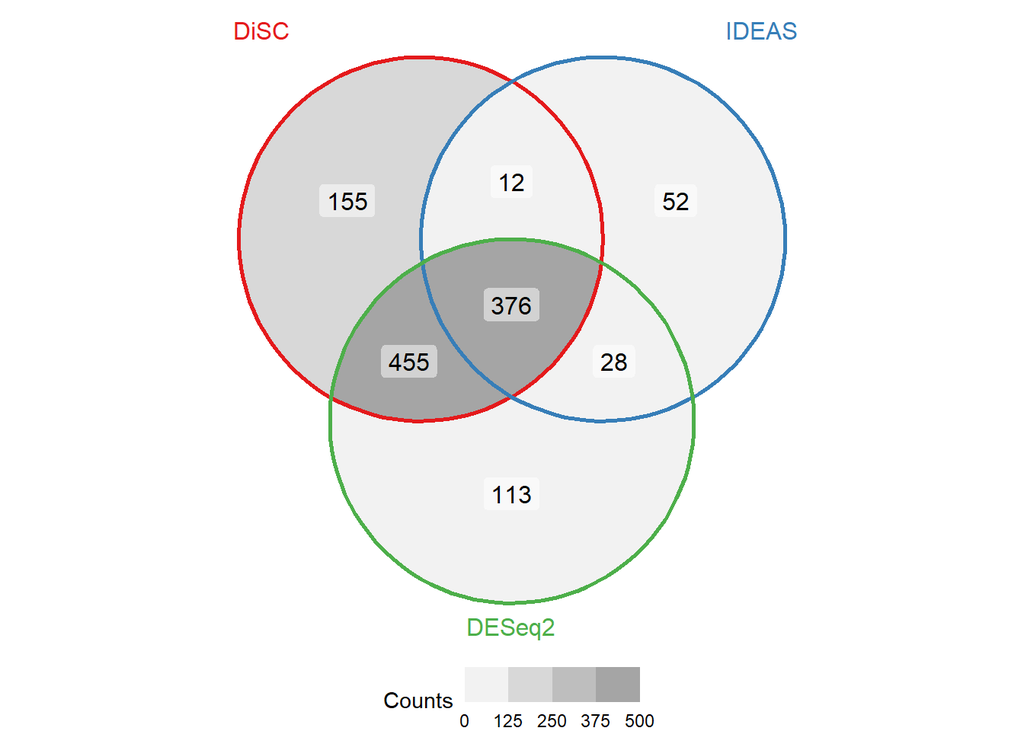

```r
Venn_break <- seq(from = 0, to = 500, length.out = 5)
# cell_to_disp <- res %>%
#   group_by(Cell_Type) %>%
#   summarise(median_across_method = median(num_sig)) %>%
#   filter(median_across_method == max(median_across_method)) %>%
#   pull(Cell_Type) %>% as.character()
Venn_AS <- res %>%
  filter(Cell_Type == "Astrocyte") %>%
  mutate(name_sig2 = str_split(name_sig, "::", simplify = FALSE)) %>%
  mutate(name_sig2 = magrittr::set_names(x = name_sig2, value = Method)) %>%
  pull(name_sig2)
Venn_AS <- Venn_AS[base::match(competing_methods, names(Venn_AS))] #df[match(target, df$name),]
figure2 <- ggVennDiagram(Venn_AS, label = c("count"),
                         set_color = RColorBrewer::brewer.pal(3, "Set1")) +
  scale_fill_steps(high = "grey60", low = "grey100", breaks = Venn_break,
                   limits = c(min(Venn_break), max(Venn_break)),name = "Counts") +
  scale_x_continuous(expand = expansion(mult = .2))+
  theme(legend.position='bottom')
Venn_OL <- res %>%
  filter(Cell_Type == "Oligodendrocyte") %>%
  mutate(name_sig2 = str_split(name_sig, "::", simplify = FALSE)) %>%
  mutate(name_sig2 = magrittr::set_names(x = name_sig2, value = Method)) %>%
  pull(name_sig2)
Venn_OL <-
  Venn_OL[base::match(competing_methods, names(Venn_OL))] #df[match(target, df$name),]
figure3 <- ggVennDiagram(Venn_OL, label = c("count"),
                         set_color = RColorBrewer::brewer.pal(3, "Set1")) +
  scale_fill_steps(high = "grey60", low = "grey100", breaks = Venn_break,
                   limits = c(min(Venn_break), max(Venn_break)),name = "Counts") +
  scale_x_continuous(expand = expansion(mult = .2))+
  theme(legend.position='bottom')
#the two figures will have the same legend as specified in
#breaks = Venn_break and limits = c(min(Venn_break), max(Venn_break))
#but it is still good to check this before align the plots
figure2
```

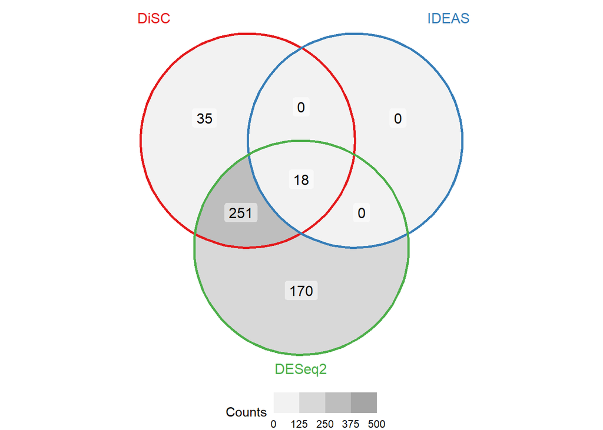

```r
figure3
```

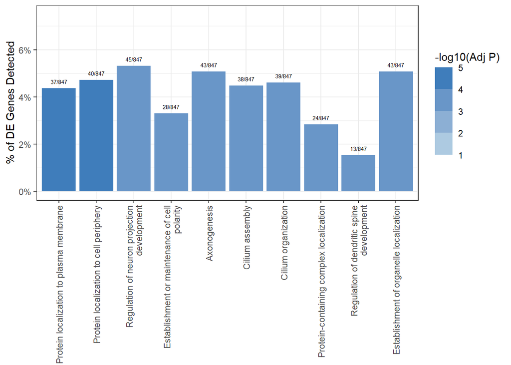

```r
figure2_3 <- lemon::grid_arrange_shared_legend(figure2, figure3,
                                               nrow = 1, position = "right") %>%
  as_ggplot()


# GO enrichment analysis
firstup <- function(x) {
  # uppercase the first letter in GO descriptions
  substr(x, 1, 1) <- toupper(substr(x, 1, 1))
  x
}
deg_AS <- res %>%
  filter(Cell_Type == "Astrocyte", Method == "DiSC") %>%
  pull(name_sig) %>%
  str_split_1(pattern = "::")
deg_AS_other_methods <- res %>%
  filter(Cell_Type == "Astrocyte", Method != "DiSC") %>%
  pull(name_sig) %>%
  str_c(collapse = "::") %>%
  str_split_1(pattern = "::") %>%
  unique()
go_enrichment_AS_BP <- enrichGO(gene = deg_AS, OrgDb = "org.Hs.eg.db",
                                 keyType = "ENSEMBL", ont = "BP")
go_enrichment_AS_BP <- go_enrichment_AS_BP %>%
  as_tibble() %>%
  mutate(Count_overlap = sapply(X = geneID,
                                FUN = \(x, g_vec){
                                  x = str_split_1(x, pattern = "/")
                                  return(sum(x %in% g_vec))},
                                simplify = TRUE, USE.NAMES =FALSE,
                                g_vec = deg_AS_other_methods),
         Count_DiSC = Count - Count_overlap) %>%
  mutate(ratio = sapply(GeneRatio, function(txt) eval(parse(text=txt)),
                        simplify = TRUE)) %>%
  mutate(`-log_p` = -log10(p.adjust))
go_enrichment_AS_BP_10 <-  go_enrichment_AS_BP %>%
  slice_max(order_by = `-log_p`, n = 10) %>%
  mutate(Description = firstup(Description)) %>%
  mutate(Description = stringr::str_wrap(Description, width = 40))

deg_OL <- res %>%
  filter(Cell_Type == "Oligodendrocyte", Method == "DiSC") %>%
  pull(name_sig) %>%
  str_split_1(pattern = "::")
deg_OL_other_methods <- res %>%
  filter(Cell_Type == "Oligodendrocyte", Method != "DiSC") %>%
  pull(name_sig) %>%
  str_c(collapse = "::") %>%
  str_split_1(pattern = "::") %>%
  unique()
go_enrichment_OL_BP <- enrichGO(gene = deg_OL, OrgDb = "org.Hs.eg.db",
                                 keyType = "ENSEMBL", ont = "BP")
go_enrichment_OL_BP <- go_enrichment_OL_BP %>%
  as_tibble() %>%
  mutate(Count_overlap = sapply(X = geneID,
                                FUN = \(x, g_vec){
                                  x = str_split_1(x, pattern = "/")
                                  return(sum(x %in% g_vec))},
                                simplify = TRUE, USE.NAMES =FALSE,
                                g_vec = deg_OL_other_methods),
         Count_DiSC = Count - Count_overlap) %>%
  mutate(ratio = sapply(GeneRatio, function(txt) eval(parse(text=txt)),
                        simplify = TRUE)) %>%
  mutate(`-log_p` = -log10(p.adjust))
go_enrichment_OL_BP_10 <-  go_enrichment_OL_BP %>%
  slice_max(order_by = `-log_p`, n = 10) %>%
  mutate(Description = firstup(Description)) %>%
  mutate(Description = stringr::str_wrap(Description, width = 40))

log_p_comb <- c(go_enrichment_AS_BP_10$`-log_p`,
                go_enrichment_OL_BP_10$`-log_p`)
go_breaks <- seq(from = floor(min(log_p_comb)), to = ceiling(max(log_p_comb)),
                 length.out = 5)
figure4 <- go_enrichment_AS_BP_10 %>%
  mutate(Description = fct_reorder(Description, `-log_p`, .desc = TRUE)) %>%
  ggplot(aes(x = Description, y = ratio, fill = `-log_p`)) +
  geom_bar(stat = "identity")+
  geom_text(label = go_enrichment_AS_BP_10$GeneRatio, vjust=-1, size = 2)+
  scale_y_continuous(labels = scales::percent, limits = c(0, 0.075)) +
  scale_fill_steps(name = "-log10(Adj P)", breaks = go_breaks,
                   limits = c(min(go_breaks), max(go_breaks)),
                   low = "#bdd7e7", high = "#2171b5")+
  theme_bw()+labs(x = NULL, y = "% of DE Genes Detected")+
  theme(axis.text.x = element_text(angle = 90, vjust = 0.5, hjust=1))
figure4
```

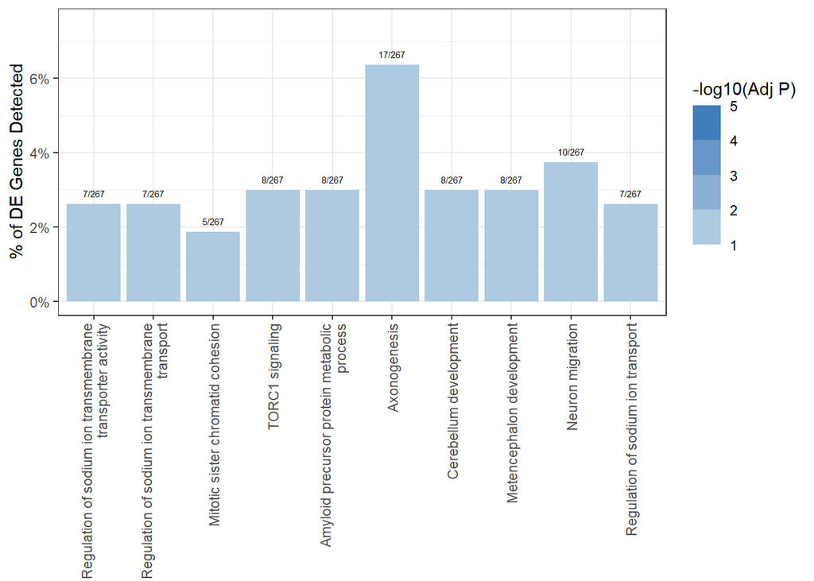

```r
figure5 <- go_enrichment_OL_BP_10 %>%
  mutate(Description = fct_reorder(Description, `-log_p`, .desc = TRUE)) %>%
  ggplot(aes(x = Description, y = ratio, fill = `-log_p`)) +
  geom_bar(stat = "identity")+
  geom_text(label = go_enrichment_OL_BP_10$GeneRatio, vjust=-1, size = 2)+
  scale_y_continuous(labels = scales::percent, limits = c(0, 0.075)) +
  scale_fill_steps(name = "-log10(Adj P)", breaks = go_breaks,
                   limits = c(min(go_breaks), max(go_breaks)),
                   low = "#bdd7e7", high = "#2171b5")+
  theme_bw()+labs(x = NULL, y = "% of DE Genes Detected")+
  theme(axis.text.x = element_text(angle = 90, vjust = 0.5, hjust=1))
figure5
```

[figure not shown]

```r
figure4_5 <- lemon::grid_arrange_shared_legend(figure4, figure5,
                                               position = "right")%>%
  as_ggplot()

figures <-
  arrangeGrob(figure1,
              figure2_3,
              figure4_5,
              layout_matrix = rbind(c(1,1), c(2,2), c(3,3), c(3, 3))) %>%
  as_ggplot() +
  draw_plot_label(label = c("(a)", "(b) AS", "(c) OL", "(d)", "(e)"),
                  x = c(0, -0.025, 0.42, 0, 0.45),
                  y = c(1, 0.75, 0.75, 0.5, 0.5),
                  size = 14, color = "black",
                  fontface = "plain", family = NULL)
figures
```

```r
ggsave(filename = "results/AD_anal_rev.pdf" , figures,
       width = 8, height = 10)
ggsave(filename = "results/AD_anal_rev.jpeg" , figures,
       width = 8, height = 10)
```

```r
# GO enrichment analysis
firstup <- function(x) {
  # uppercase the first letter in GO descriptions
  substr(x, 1, 1) <- toupper(substr(x, 1, 1))
  x
}

deg_AS <- res %>%
  filter(Cell_Type == "Astrocyte", Method == "DiSC") %>%
  pull(name_sig) %>%
  str_split_1(pattern = "::")
deg_AS_DESeq2 <- res %>%
  filter(Cell_Type == "Astrocyte", Method == "DESeq2") %>%
  pull(name_sig) %>%
  str_split_1(pattern = "::")
length(deg_AS_DESeq2)
```

```
## [1] 972
```

```r
length(setdiff(deg_AS_DESeq2, deg_AS))
```

```
## [1] 141
```

```r
go_enrichment_AS_BP <- enrichGO(gene = setdiff(deg_AS_DESeq2, deg_AS),
                                OrgDb = "org.Hs.eg.db",
                                keyType = "ENSEMBL", ont = "BP")
go_enrichment_AS_BP <- go_enrichment_AS_BP %>%
  as_tibble() %>%
  mutate(Count_overlap = sapply(X = geneID,
                                FUN = \(x, g_vec){
                                  x = str_split_1(x, pattern = "/")
                                  return(sum(x %in% g_vec))},
                                simplify = TRUE, USE.NAMES =FALSE,
                                g_vec = deg_AS_other_methods),
         Count_DiSC = Count - Count_overlap) %>%
  mutate(ratio = sapply(GeneRatio, function(txt) eval(parse(text=txt)),
                        simplify = TRUE)) %>%
  mutate(`-log_p` = -log10(p.adjust))
go_enrichment_AS_BP %>%
  mutate(Description = firstup(Description)) %>%
  dplyr::select(Description, GeneRatio, p.adjust, `-log_p`) %>%
  slice_max(order_by = `-log_p`, n = 10) %>%
  print()
```

```
## # A tibble: 2 × 4
##   Description                          GeneRatio p.adjust `-log_p`
##   <chr>                                <chr>        <dbl>    <dbl>
## 1 Regulation of lipase activity        6/127       0.0232     1.63
## 2 Regulation of phospholipase activity 5/127       0.0446     1.35
```

```r
deg_OL <- res %>%
  filter(Cell_Type == "Oligodendrocyte", Method == "DiSC") %>%
  pull(name_sig) %>%
  str_split_1(pattern = "::")
deg_OL_DESeq2 <- res %>%
  filter(Cell_Type == "Oligodendrocyte", Method == "DESeq2") %>%
  pull(name_sig) %>%
  str_split_1(pattern = "::")
length(deg_OL_DESeq2)
```

```
## [1] 439
```

```r
length(setdiff(deg_OL_DESeq2, deg_OL))
```

```
## [1] 170
```

```r
go_enrichment_OL_BP <- enrichGO(gene = setdiff(deg_OL_DESeq2, deg_OL),
                                OrgDb = "org.Hs.eg.db",
                                keyType = "ENSEMBL", ont = "BP")
go_enrichment_OL_BP <- go_enrichment_OL_BP %>%
  as_tibble() %>%
  mutate(Count_overlap = sapply(X = geneID,
                                FUN = \(x, g_vec){
                                  x = str_split_1(x, pattern = "/")
                                  return(sum(x %in% g_vec))},
                                simplify = TRUE, USE.NAMES =FALSE,
                                g_vec = deg_OL_other_methods),
         Count_DiSC = Count - Count_overlap) %>%
  mutate(ratio = sapply(GeneRatio, function(txt) eval(parse(text=txt)),
                        simplify = TRUE)) %>%
  mutate(`-log_p` = -log10(p.adjust))
go_enrichment_OL_BP %>%
  mutate(Description = firstup(Description)) %>%
  dplyr::select(Description, GeneRatio, p.adjust, `-log_p`) %>%
  slice_max(order_by = `-log_p`, n = 10) %>%
  print()
```

```
## # A tibble: 10 × 4
##    Description                                    GeneRatio p.adjust `-log_p`
##    <chr>                                          <chr>        <dbl>    <dbl>
##  1 Axon extension                                 9/152      0.00114     2.94
##  2 Regulation of cellular component size          14/152     0.00114     2.94
##  3 Neuron projection extension                    10/152     0.00114     2.94
##  4 Regulation of extent of cell growth            8/152      0.00114     2.94
##  5 Regulation of cell size                        10/152     0.00114     2.94
##  6 Developmental cell growth                      11/152     0.00117     2.93
##  7 Regulation of developmental growth             12/152     0.00271     2.57
##  8 Regulation of axon extension                   7/152      0.00271     2.57
##  9 Developmental growth involved in morphogenesis 10/152     0.00582     2.24
## 10 Regulation of axonogenesis                     8/152      0.00779     2.11
```

## Could you compare your results to the new baselines iDESC and BSDE not only for the simulations, but also on the new SEA-AD dataset?

```r
DATE = "0119"
pval_thre = 0.10
competing_methods = c("DiSC", "IDEAS", "DESeq2", "BSDE", "iDESC")
#list the results and convert them to a dataframe
res <- list.files("res_to_rev/AD2") %>%
  # should look like "d@COVIDPBMC-m@DESeq2-v@0612-c@B_cell.rds"
  # "varname@value" and splitted by "-"
  str_subset(pattern = ".rds$") %>%
  str_remove(pattern = ".rds$") %>%
  sapply(X = ., simplify = FALSE, FUN = \(x){
    temp <- str_split(str_split_1(x, "-"), "@", simplify = TRUE)
    return(c(filname = str_glue("{x}.rds"),
             setNames(object = temp[,2], nm = temp[,1])))
  }) %>%
  bind_rows()

res <- res %>%
  filter(d == "AD2" & v == DATE) %>%
  dplyr::rename(Method = "m", Cell_Type = "c")
num_sig <- numeric(nrow(res))
name_sig <- character(nrow(res))
for(rr in 1:nrow(res)){
  pval_mat <- readRDS(str_glue("res_to_rev/AD2/{res$filname[rr]}"))
  sig_genes <- colnames(pval_mat)[pval_mat["adjusted", ] <= pval_thre]
  sig_genes <- sig_genes[!is.na(sig_genes)] # some values can be NAs in DESeq2
  name_sig[rr] <- str_c(sig_genes, collapse = "::")
  num_sig[rr] <- length(sig_genes)
  rm(pval_mat)
}
res <- res %>%
  mutate(num_sig = num_sig, name_sig = name_sig) %>%
  mutate(Method = factor(Method, levels = competing_methods)) %>%
  mutate(Cell_Type = factor(Cell_Type)) %>%
  # order the cell types according to the how many significant genes DiSC found
  mutate(Cell_Type = fct_reorder2(.f = Cell_Type, .x = Method, .y = num_sig,
                                  .desc = FALSE,
                                  .fun = \(.x, .y) return(.y[.x == "DiSC"])))

more_than_IDEAS_BSDE_iDESC <- res %>%
  group_by(Cell_Type) %>%
  summarise(more_than_IDEAS = num_sig[Method == "DiSC"] -
              num_sig[Method == "IDEAS"],
            more_than_BSDE = num_sig[Method == "DiSC"] -
              num_sig[Method == "BSDE"],
            more_than_iDESC = num_sig[Method == "DiSC"] -
              num_sig[Method == "iDESC"],) %>%
  arrange(desc(more_than_IDEAS))
print(more_than_IDEAS_BSDE_iDESC, n=30)
```

```
## # A tibble: 22 × 4
##    Cell_Type       more_than_IDEAS more_than_BSDE more_than_iDESC
##    <fct>                     <dbl>          <dbl>           <dbl>
##  1 L4_IT                      1203          -2920            -354
##  2 Vip                        1181           1419            1271
##  3 L6_IT_Car3                 1086           1695            1057
##  4 Sst                         740            493            -998
##  5 Astrocyte                   542           1022             967
##  6 Oligodendrocyte             291            -56             247
##  7 OPC                          39            125              87
##  8 L5_ET                         2          -3713            -605
##  9 VLMC                          1              1              -2
## 10 Endothelial                   0              0               0
## 11 L6_IT                        -7           1322             733
## 12 Sncg                       -134           1047            -266
## 13 Microglia_PVM              -138          -1557           -1108
## 14 L6b                        -177            816             782
## 15 L5_IT                      -246          -3613           -2016
## 16 L6_CT                      -391           1207             602
## 17 L5_6_NP                    -398           1191             742
## 18 Pax6                      -1028            264             215
## 19 Lamp5_Lhx6                -1089           1038             952
## 20 Chandelier                -1114            550            -260
## 21 Lamp5                     -1124            579             329
## 22 Pvalb                     -1164          -4733           -3415
```

```r
wilcox.test(more_than_IDEAS_BSDE_iDESC$more_than_IDEAS)
```

```
##
##  Wilcoxon signed rank test with continuity correction
##
## data:  more_than_IDEAS_BSDE_iDESC$more_than_IDEAS
## V = 97, p-value = 0.5316
## alternative hypothesis: true location is not equal to 0
```

```r
wilcox.test(more_than_IDEAS_BSDE_iDESC$more_than_BSDE)
```

```
##
##  Wilcoxon signed rank test with continuity correction
##
## data:  more_than_IDEAS_BSDE_iDESC$more_than_BSDE
## V = 135, p-value = 0.509
## alternative hypothesis: true location is not equal to 0
```

```r
# Number of positive findings in the SEA-AD dataset
res %>% dplyr::select(Method, Cell_Type, num_sig) %>%
  arrange(desc(Cell_Type), Method) %>% # order a factor
  pivot_wider(names_from = Cell_Type, values_from = num_sig) %>%
  kbl(digits = 4,
      caption = "Number of Positive Findings in COVID-PBMC dataset(Adjusted for FDR)") %>%
  kable_classic(full_width = F, html_font = "Cambria")
```

| Method | Sst | L6_IT_Car3 | L6b | L6_IT | Lamp5_Lhx6 | L4_IT | Vip | L6_CT | L5_6_NP | Sncg | Astrocyte | L5_IT | Lamp5 | Chandelier | Oligodendrocyte | Pax6 | Microglia_PVM | OPC | Pvalb | L5_ET | VLMC | Endothelial |
| --- | --- | --- | --- | --- | --- | --- | --- | --- | --- | --- | --- | --- | --- | --- | --- | --- | --- | --- | --- | --- | --- | --- |
| DiSC | 2005 | 1709 | 1677 | 1629 | 1424 | 1420 | 1419 | 1410 | 1191 | 1102 | 1046 | 849 | 586 | 581 | 310 | 264 | 134 | 133 | 12 | 2 | 1 | 0 |
| IDEAS | 1265 | 623 | 1854 | 1636 | 2513 | 217 | 238 | 1801 | 1589 | 1236 | 504 | 1095 | 1710 | 1695 | 19 | 1292 | 272 | 94 | 1176 | 0 | 0 | 0 |
| DESeq2 | 1364 | 1549 | 1706 | 1763 | 1678 | 2256 | 1742 | 1597 | 1112 | 613 | 1013 | 1927 | 1454 | 897 | 458 | 787 | 388 | 292 | 2078 | 124 | 15 | 0 |
| BSDE | 1512 | 14 | 861 | 307 | 386 | 4340 | 0 | 203 | 0 | 55 | 24 | 4462 | 7 | 31 | 366 | 0 | 1691 | 8 | 4745 | 3715 | 0 | 0 |
| iDESC | 3003 | 652 | 895 | 896 | 472 | 1774 | 148 | 808 | 449 | 1368 | 79 | 2865 | 257 | 841 | 63 | 49 | 1242 | 46 | 3427 | 607 | 3 | 0 |

```r
figure1 <- res %>%
  ggplot(., aes(x=Cell_Type, color=Method, fill=Method, y=num_sig)) +
  geom_bar(stat = "identity",
           position = position_dodge2(padding = 0.6, reverse = TRUE),
           width=0.7) +
  scale_y_sqrt()+
  xlab("Cell Types") +
  ylab("Number of DE Genes Detected")+
  theme_bw() + coord_flip() +
  scale_color_brewer(palette = "Set1") +
  scale_fill_brewer(palette = "Set1") +
  theme(legend.position='right')

# Overlaps in positive findings of AS and Oligodendrocyte between methods
Venn_break <- res %>% filter(Cell_Type %in% c("Astrocyte", "Oligodendrocyte"))
Venn_break
```

```
## # A tibble: 10 × 7
##    filname                         d     Method v     Cell_Type num_sig name_sig
##    <chr>                           <chr> <fct>  <chr> <fct>       <dbl> <chr>
##  1 d@AD2-m@BSDE-v@0119-c@Astrocyt… AD2   BSDE   0119  Astrocyte      24 ENSG000…
##  2 d@AD2-m@BSDE-v@0119-c@Oligoden… AD2   BSDE   0119  Oligoden…     366 ENSG000…
##  3 d@AD2-m@DESeq2-v@0119-c@Astroc… AD2   DESeq2 0119  Astrocyte    1013 ENSG000…
##  4 d@AD2-m@DESeq2-v@0119-c@Oligod… AD2   DESeq2 0119  Oligoden…     458 ENSG000…
##  5 d@AD2-m@DiSC-v@0119-c@Astrocyt… AD2   DiSC   0119  Astrocyte    1046 ENSG000…
##  6 d@AD2-m@DiSC-v@0119-c@Oligoden… AD2   DiSC   0119  Oligoden…     310 ENSG000…
##  7 d@AD2-m@IDEAS-v@0119-c@Astrocy… AD2   IDEAS  0119  Astrocyte     504 ENSG000…
##  8 d@AD2-m@IDEAS-v@0119-c@Oligode… AD2   IDEAS  0119  Oligoden…      19 ENSG000…
##  9 d@AD2-m@iDESC-v@0119-c@Astrocy… AD2   iDESC  0119  Astrocyte      79 ENSG000…
## 10 d@AD2-m@iDESC-v@0119-c@Oligode… AD2   iDESC  0119  Oligoden…      63 ENSG000…
```

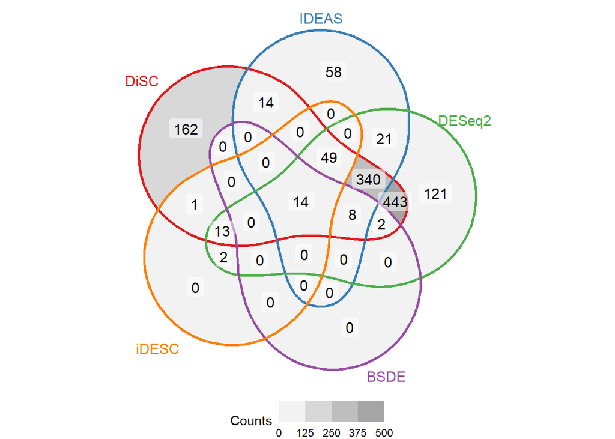

```r
Venn_break <- seq(from = 0, to = 500, length.out = 5)
# cell_to_disp <- res %>%
#   group_by(Cell_Type) %>%
#   summarise(median_across_method = median(num_sig)) %>%
#   filter(median_across_method == max(median_across_method)) %>%
#   pull(Cell_Type) %>% as.character()
Venn_AS <- res %>%
  filter(Cell_Type == "Astrocyte") %>%
  mutate(name_sig2 = str_split(name_sig, "::", simplify = FALSE)) %>%
  mutate(name_sig2 = magrittr::set_names(x = name_sig2, value = Method)) %>%
  pull(name_sig2)
Venn_AS <- Venn_AS[base::match(competing_methods, names(Venn_AS))] #df[match(target, df$name),]
figure2 <- ggVennDiagram(Venn_AS, label = c("count"),
                         set_color = RColorBrewer::brewer.pal(5, "Set1")) +
  scale_fill_steps(high = "grey60", low = "grey100", breaks = Venn_break,
                   limits = c(min(Venn_break), max(Venn_break)),name = "Counts") +
  scale_x_continuous(expand = expansion(mult = .2))+
  theme(legend.position='bottom')
Venn_OL <- res %>%
  filter(Cell_Type == "Oligodendrocyte") %>%
  mutate(name_sig2 = str_split(name_sig, "::", simplify = FALSE)) %>%
  mutate(name_sig2 = magrittr::set_names(x = name_sig2, value = Method)) %>%
  pull(name_sig2)
Venn_OL <-
  Venn_OL[base::match(competing_methods, names(Venn_OL))] #df[match(target, df$name),]
figure3 <- ggVennDiagram(Venn_OL, label = c("count"),
                         set_color = RColorBrewer::brewer.pal(5, "Set1")) +
  scale_fill_steps(high = "grey60", low = "grey100", breaks = Venn_break,
                   limits = c(min(Venn_break), max(Venn_break)),name = "Counts") +
  scale_x_continuous(expand = expansion(mult = .2))+
  theme(legend.position='bottom')
#the two figures will have the same legend as specified in
#breaks = Venn_break and limits = c(min(Venn_break), max(Venn_break))
#but it is still good to check this before align the plots
figure2
```

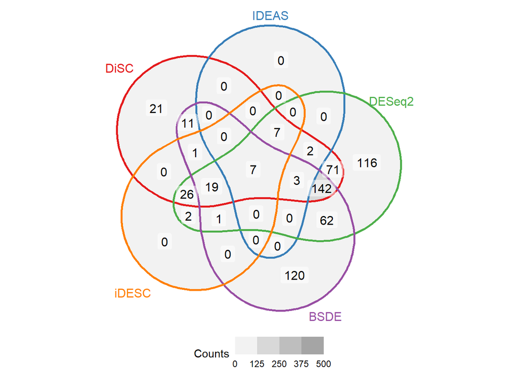

```r
figure3
```

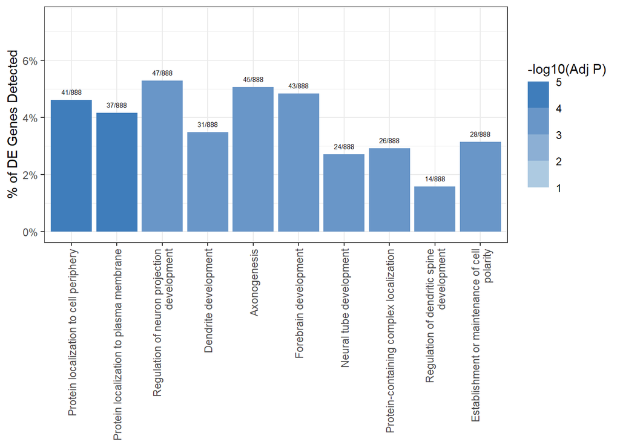

```r
figure2_3 <- lemon::grid_arrange_shared_legend(figure2, figure3,
                                               nrow = 1, position = "right") %>%
  as_ggplot()


# GO enrichment analysis
firstup <- function(x) {
  # uppercase the first letter in GO descriptions
  substr(x, 1, 1) <- toupper(substr(x, 1, 1))
  x
}
deg_AS <- res %>%
  filter(Cell_Type == "Astrocyte", Method == "DiSC") %>%
  pull(name_sig) %>%
  str_split_1(pattern = "::")
deg_AS_other_methods <- res %>%
  filter(Cell_Type == "Astrocyte", Method != "DiSC") %>%
  pull(name_sig) %>%
  str_c(collapse = "::") %>%
  str_split_1(pattern = "::") %>%
  unique()
go_enrichment_AS_BP <- enrichGO(gene = deg_AS, OrgDb = "org.Hs.eg.db",
                                 keyType = "ENSEMBL", ont = "BP")
go_enrichment_AS_BP <- go_enrichment_AS_BP %>%
  as_tibble() %>%
  mutate(Count_overlap = sapply(X = geneID,
                                FUN = \(x, g_vec){
                                  x = str_split_1(x, pattern = "/")
                                  return(sum(x %in% g_vec))},
                                simplify = TRUE, USE.NAMES =FALSE,
                                g_vec = deg_AS_other_methods),
         Count_DiSC = Count - Count_overlap) %>%
  mutate(ratio = sapply(GeneRatio, function(txt) eval(parse(text=txt)),
                        simplify = TRUE)) %>%
  mutate(`-log_p` = -log10(p.adjust))
go_enrichment_AS_BP_10 <-  go_enrichment_AS_BP %>%
  slice_max(order_by = `-log_p`, n = 10) %>%
  mutate(Description = firstup(Description)) %>%
  mutate(Description = stringr::str_wrap(Description, width = 40))

deg_OL <- res %>%
  filter(Cell_Type == "Oligodendrocyte", Method == "DiSC") %>%
  pull(name_sig) %>%
  str_split_1(pattern = "::")
deg_OL_other_methods <- res %>%
  filter(Cell_Type == "Oligodendrocyte", Method != "DiSC") %>%
  pull(name_sig) %>%
  str_c(collapse = "::") %>%
  str_split_1(pattern = "::") %>%
  unique()
go_enrichment_OL_BP <- enrichGO(gene = deg_OL, OrgDb = "org.Hs.eg.db",
                                 keyType = "ENSEMBL", ont = "BP")
go_enrichment_OL_BP <- go_enrichment_OL_BP %>%
  as_tibble() %>%
  mutate(Count_overlap = sapply(X = geneID,
                                FUN = \(x, g_vec){
                                  x = str_split_1(x, pattern = "/")
                                  return(sum(x %in% g_vec))},
                                simplify = TRUE, USE.NAMES =FALSE,
                                g_vec = deg_OL_other_methods),
         Count_DiSC = Count - Count_overlap) %>%
  mutate(ratio = sapply(GeneRatio, function(txt) eval(parse(text=txt)),
                        simplify = TRUE)) %>%
  mutate(`-log_p` = -log10(p.adjust))
go_enrichment_OL_BP_10 <-  go_enrichment_OL_BP %>%
  slice_max(order_by = `-log_p`, n = 10) %>%
  mutate(Description = firstup(Description)) %>%
  mutate(Description = stringr::str_wrap(Description, width = 40))

log_p_comb <- c(go_enrichment_AS_BP_10$`-log_p`,
                go_enrichment_OL_BP_10$`-log_p`)
go_breaks <- seq(from = floor(min(log_p_comb)), to = ceiling(max(log_p_comb)),
                 length.out = 5)
figure4 <- go_enrichment_AS_BP_10 %>%
  mutate(Description = fct_reorder(Description, `-log_p`, .desc = TRUE)) %>%
  ggplot(aes(x = Description, y = ratio, fill = `-log_p`)) +
  geom_bar(stat = "identity")+
  geom_text(label = go_enrichment_AS_BP_10$GeneRatio, vjust=-1, size = 2)+
  scale_y_continuous(labels = scales::percent, limits = c(0, 0.075)) +
  scale_fill_steps(name = "-log10(Adj P)", breaks = go_breaks,
                   limits = c(min(go_breaks), max(go_breaks)),
                   low = "#bdd7e7", high = "#2171b5")+
  theme_bw()+labs(x = NULL, y = "% of DE Genes Detected")+
  theme(axis.text.x = element_text(angle = 90, vjust = 0.5, hjust=1))
figure4
```

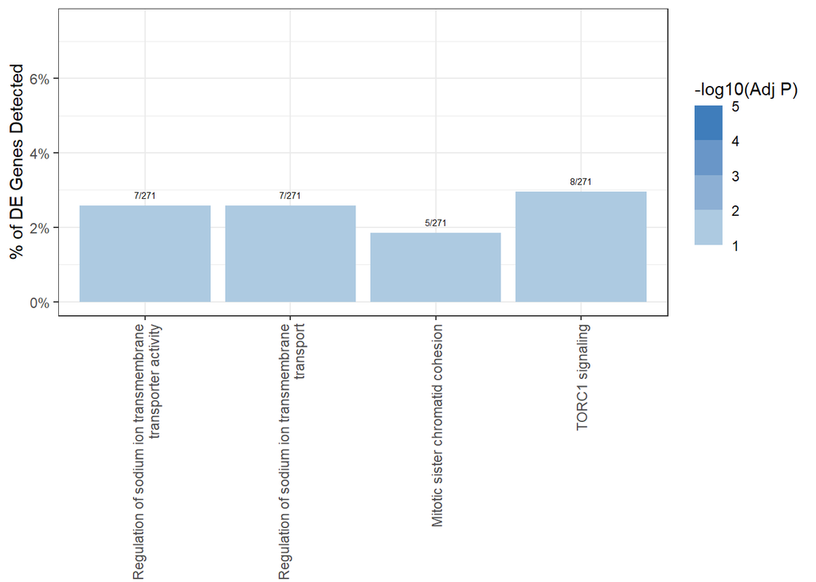

```r
figure5 <- go_enrichment_OL_BP_10 %>%
  mutate(Description = fct_reorder(Description, `-log_p`, .desc = TRUE)) %>%
  ggplot(aes(x = Description, y = ratio, fill = `-log_p`)) +
  geom_bar(stat = "identity")+
  geom_text(label = go_enrichment_OL_BP_10$GeneRatio, vjust=-1, size = 2)+
  scale_y_continuous(labels = scales::percent, limits = c(0, 0.075)) +
  scale_fill_steps(name = "-log10(Adj P)", breaks = go_breaks,
                   limits = c(min(go_breaks), max(go_breaks)),
                   low = "#bdd7e7", high = "#2171b5")+
  theme_bw()+labs(x = NULL, y = "% of DE Genes Detected")+
  theme(axis.text.x = element_text(angle = 90, vjust = 0.5, hjust=1))
figure5
```

[figure not shown]

```r
figure4_5 <- lemon::grid_arrange_shared_legend(figure4, figure5,
                                               position = "right")%>%
  as_ggplot()

figures <-
  arrangeGrob(figure1,
              figure2_3,
              figure4_5,
              layout_matrix = rbind(c(1,1), c(2,2), c(3,3), c(3, 3))) %>%
  as_ggplot() +
  draw_plot_label(label = c("(a)", "(b) AS", "(c) OL", "(d)", "(e)"),
                  x = c(0, -0.025, 0.42, 0, 0.45),
                  y = c(1, 0.75, 0.75, 0.5, 0.5),
                  size = 14, color = "black",
                  fontface = "plain", family = NULL)
figures
```

```r
ggsave(filename = "results/AD_anal_rev_r2.pdf" , figures,
       width = 8, height = 20)
ggsave(filename = "results/AD_anal_rev_r2.jpeg" , figures,
       width = 8, height = 20)
```

## Illustrate how distributional characteristics are extracted and transformed

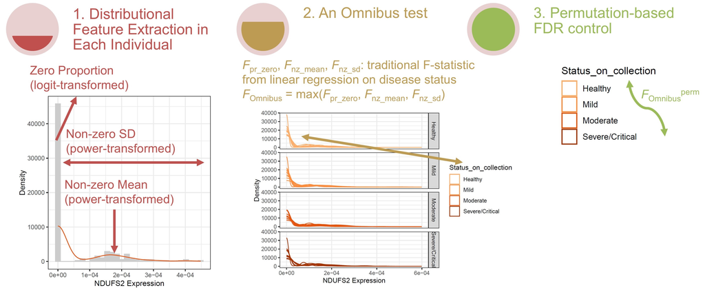

A Schematic Diagram Illustrating the Differential Expression of NDUSF2 in CD8+ T Cells Between COVID-19 Patients and Healthy Controls Using DiSC.

## An ablation study analysing the influence of the normalisation strategy

```r
p_val_thre <- 0.10

load("supp_info_anal/n12_12_d1.3_c375_vFALSE_0811_b1.RData")
dat_list[["meta_ind"]]$phenotype <- as.factor(dat_list[["meta_ind"]]$phenotype)
dat_list[["meta_cell"]]$phenotype <- as.factor(dat_list[["meta_cell"]]$phenotype)
count_matrix <- dat_list$count_matrix
meta_cell <- dat_list$meta_cell
meta_ind <- dat_list$meta_ind
gene_index <- dat_list$gene_index

set.seed(seed = 123456)

inds <- unique(meta_cell[["individual"]])
meta_ind <- meta_ind[base::match(inds, meta_ind[["individual"]]), ]
data_mat <- count_matrix
depth <- colSums(data_mat)
cell.list <- list()
for (ind in inds)
  cell.list[[ind]] <- meta_cell[meta_cell$individual == ind, ][["cell_id"]]
log_md_depth <- numeric(length = length(inds))
names(log_md_depth) <- inds
for(ind in inds)
  log_md_depth[ind] <- log(median(depth[cell.list[[ind]]]))
meta_ind$log_md_depth <- log_md_depth

# # Original
# obj_ori <-
#   DiSC(data.mat = data_mat, cell.ind = meta_cell,
#        metadata = meta_ind, outcome = "phenotype",
#        covariates = c("RIN"),
#        cell.id = "cell_id", individual.id = "individual",
#        perm.no = 999, verbose = FALSE, sequencing.data = TRUE,
#        features = c('prev', 'nzm', 'nzsd'))

# log2 transformed
data_mat_log <- log2(data_mat+1)
obj_log <-
  DiSC(data.mat = data_mat_log, cell.ind = meta_cell,
       metadata = meta_ind, outcome = "phenotype",
       covariates = c("RIN"),
       cell.id = "cell_id", individual.id = "individual",
       perm.no = 999, verbose = FALSE, sequencing.data = FALSE,
       features = c('prev', 'nzm', 'nzsd'))
# log2 transformed, adjusted for log median sequencing depth
obj_log_adj <-
  DiSC(data.mat = data_mat_log, cell.ind = meta_cell,
       metadata = meta_ind, outcome = "phenotype",
       covariates = c("RIN", "log_md_depth"),
       cell.id = "cell_id", individual.id = "individual",
       perm.no = 999, verbose = FALSE, sequencing.data = FALSE,
       features = c('prev', 'nzm', 'nzsd'))
# Total sum
data_mat_tts <- t(t(data_mat) / depth)
obj_tts <-
  DiSC(data.mat = data_mat_tts, cell.ind = meta_cell,
       metadata = meta_ind, outcome = "phenotype",
       covariates = c("RIN"),
       cell.id = "cell_id", individual.id = "individual",
       perm.no = 999, verbose = FALSE, sequencing.data = FALSE,
       features = c('prev', 'nzm', 'nzsd'))
# Total sum, adjusted for log median sequencing depth
obj_tts_adj <-
  DiSC(data.mat = data_mat_tts, cell.ind = meta_cell,
       metadata = meta_ind, outcome = "phenotype",
       covariates = c("RIN", "log_md_depth"),
       cell.id = "cell_id", individual.id = "individual",
       perm.no = 999, verbose = FALSE, sequencing.data = FALSE,
       features = c('prev', 'nzm', 'nzsd'))
# Size factor: Trimmed Mean of M-values
dge <- DGEList(counts = data_mat,
               group = rep(meta_ind$phenotype, each = 375))
dge <- calcNormFactors(dge, method = "TMM")
data_mat_tmm <- sweep(data_mat, 2, dge$samples$norm.factors, FUN = "/")
obj_tmm <-
  DiSC(data.mat = data_mat_tmm, cell.ind = meta_cell,
       metadata = meta_ind, outcome = "phenotype",
       covariates = c("RIN"),
       cell.id = "cell_id", individual.id = "individual",
       perm.no = 999, verbose = FALSE, sequencing.data = FALSE,
       features = c('prev', 'nzm', 'nzsd'))
# Size factor: Trimmed Mean of M-values, adjusted for log median sequencing depth
obj_tmm_adj <-
  DiSC(data.mat = data_mat_tmm, cell.ind = meta_cell,
       metadata = meta_ind, outcome = "phenotype",
       covariates = c("RIN", "log_md_depth"),
       cell.id = "cell_id", individual.id = "individual",
       perm.no = 999, verbose = FALSE, sequencing.data = FALSE,
       features = c('prev', 'nzm', 'nzsd'))
# Size factor: DESeq2
colData <- data.frame(condition = rep(meta_ind$phenotype, each = 375),
                      row.names = colnames(data_mat))
dds <- DESeq2::DESeqDataSetFromMatrix(countData = data_mat + 1,
                                      # avoid every gene contains at least one zero
                                      colData = colData, design = ~ condition)
dds <- DESeq2::estimateSizeFactors(dds)
data_mat_des <- sweep(data_mat, 2, DESeq2::sizeFactors(dds), FUN = "/")
obj_des <-
  DiSC(data.mat = data_mat_des, cell.ind = meta_cell,
       metadata = meta_ind, outcome = "phenotype",
       covariates = c("RIN"),
       cell.id = "cell_id", individual.id = "individual",
       perm.no = 999, verbose = FALSE, sequencing.data = FALSE,
       features = c('prev', 'nzm', 'nzsd'))
# Size factor: DESeq2, adjusted for log median sequencing depth
obj_des_adj <-
  DiSC(data.mat = data_mat_des, cell.ind = meta_cell,
       metadata = meta_ind, outcome = "phenotype",
       covariates = c("RIN", "log_md_depth"),
       cell.id = "cell_id", individual.id = "individual",
       perm.no = 999, verbose = FALSE, sequencing.data = FALSE,
       features = c('prev', 'nzm', 'nzsd'))
# # rarefaction
# data_mat_rrf <- t(GUniFrac::Rarefy(t(data_mat))$otu.tab.rff)
# obj_rrf <-
#   DiSC(data.mat = data_mat_rrf, cell.ind = meta_cell,
#        metadata = meta_ind, outcome = "phenotype",
#        covariates = c("RIN"),
#        cell.id = "cell_id", individual.id = "individual",
#        perm.no = 999, verbose = FALSE, sequencing.data = FALSE,
#        features = c('prev', 'nzm', 'nzsd'))

gene_stra <- unlist(gene_index) %>%
  sort() %>% names() %>% str_extract(pattern = "\\w+_index")
# gene_stra[gene_index$mean_index[1:10]] # mean_index
p_cat <- cut(obj_tts_adj$p.adj.fdr,
             breaks = c(-1, 0.001, 0.01, 0.05, 0.10, +Inf),
             labels = c("<= 0.001", "0.001 - 0.01",
                        "0.01 - 0.05", "0.05 - 0.10",
                        "> 0.10"))
norm_results <-
  tibble("P value category" = p_cat, "Gene stratum" = gene_stra,
         "Total sum" = obj_tts$p.adj.fdr, "log2-transformed" = obj_log$p.adj.fdr,
         "Trimmed mean of M-values" = obj_tmm$p.adj.fdr,
         "DESeq2 size factor" = obj_des$p.adj.fdr,
         "Total sum, adjusted (implemented)" = obj_tts_adj$p.adj.fdr,
         "log2 transformed, adjusted" = obj_log_adj$p.adj.fdr,
         "Trimmed mean of M-values, adjusted" = obj_tmm_adj$p.adj.fdr,
         "DESeq2 size factor, adjusted" = obj_des_adj$p.adj.fdr)

norm_results %>% group_by(`P value category`, `Gene stratum`) %>%
  slice_head(n = 1) %>%
  kbl(digits = 4,
      caption = str_glue("Influence of different normalization methods in FDR-adjusted P values")) %>%
  kable_classic(full_width = F, html_font = "Cambria") %>%
  print()
```

[output not shown]

[output cut: 192 more lines]

[output not shown]

```r
norm_results %>%
  group_by(`Gene stratum`) %>%
  summarise(
    across(`Total sum`:`DESeq2 size factor, adjusted`,
           \(x) mean(x < p_val_thre)*100
           )) %>%
  filter(`Gene stratum` != "EE_index") %>%
  kbl(digits = 4,
      caption = str_glue("Influence of different normalization methods in true positive rate (%)")) %>%
  kable_classic(full_width = F, html_font = "Cambria") %>%
  print()
```

[output not shown]

# References

- Gabitto, M. I., Travaglini, K. J., Rachleff, V. M., Kaplan, E. S., Long, B., Ariza, J., … & Lein, E. S. (2024). Integrated multimodal cell atlas of Alzheimer’s disease. *Nature Neuroscience*, 1-18.